# Code for longitudinal SBP and SHT analysis in cats

```
## Some of the focal terms are of type `character`. This may lead to
##   unexpected results. It is recommended to convert these variables to
##   factors before fitting the model.
##   The following variables are of type character: `Overall_health_status`
```

```
## Model contains splines or polynomial terms. Consider using
##   `terms="Age_years [all]"` to get smooth plots. See also package-vignette
##   'Adjusted Predictions at Specific Values'.
```

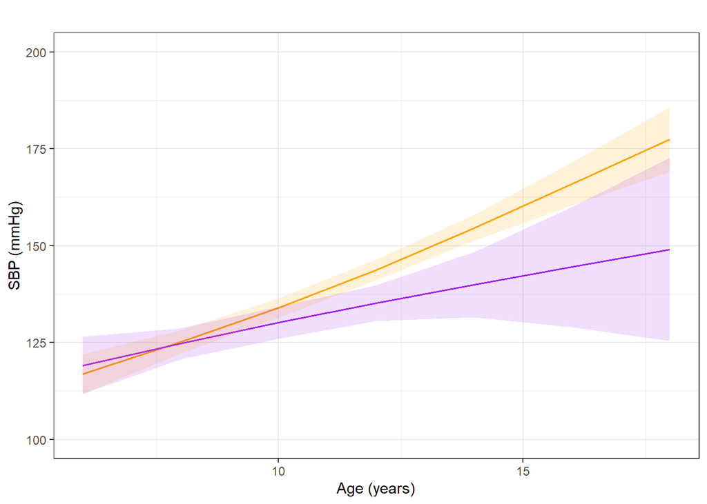

```r
plot_model(mod_int, type="emm", terms=c("Age_years", "Overall_health_status"), colors = c("orange", "purple"))+
  xlab("Age (years)") +
  ylab("SBP (mmHg)") +
  ggtitle("") +
  theme_bw() +
  theme(legend.position = "none")+
  scale_y_continuous(limits = c(100, 200))
```

```r
Metadata_SBP2%>% filter (Overall_health_status=="Healthy") %>%   summarise(n_healthy_cats = n_distinct(Cat_ID))
```

```
##   n_healthy_cats
## 1             69
```

```r
#
ggsave("Fig3_age_health_interactions.png", plot= last_plot(), bg = "white", height =10, width = 15, units="cm" )
```

#####Check mod assumptions

```r
check5<-check_model(mod_int)
png("check5.png", width = 3000, height = 4000, res = 300)
print(check5)
dev.off()
```

```r
check_collinearity(mod_int)
```

```
## Model has interaction terms. VIFs might be inflated.
##   Try to center the variables used for the interaction, or check
##   multicollinearity among predictors of a model without interaction terms.
```

```
## # Check for Multicollinearity
##
## Low Correlation
##
##                   Term  VIF     VIF 95% CI adj. VIF Tolerance Tolerance 95% CI
##                    Sex 3.26 [ 2.96,  3.61]     1.81      0.31     [0.28, 0.34]
##  Overall_health_status 3.12 [ 2.83,  3.44]     1.77      0.32     [0.29, 0.35]
##
## Moderate Correlation
##
##                       Term  VIF     VIF 95% CI adj. VIF Tolerance
##  ns(Age_years, df = 2):Sex 8.53 [ 7.66,  9.53]     2.92      0.12
##  Tolerance 95% CI
##      [0.10, 0.13]
##
## High Correlation
##
##                                         Term   VIF     VIF 95% CI adj. VIF
##                        ns(Age_years, df = 2) 41.21 [36.75, 46.23]     6.42
##  ns(Age_years, df = 2):Overall_health_status 57.28 [51.06, 64.28]     7.57
##  Tolerance Tolerance 95% CI
##       0.02     [0.02, 0.03]
##       0.02     [0.02, 0.02]
```

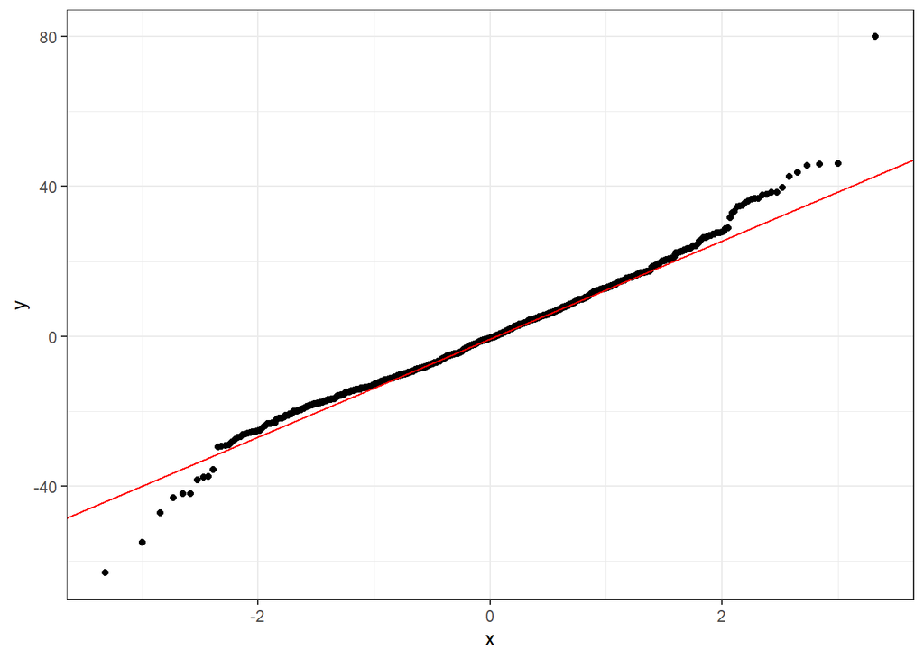

```r
# Extract residuals
res <- residuals(mod_int)
#qq plot of resids
ggplot(data.frame(res), aes(sample = res)) +
  stat_qq() +
  stat_qq_line(color = "red") +
  theme_bw()
```

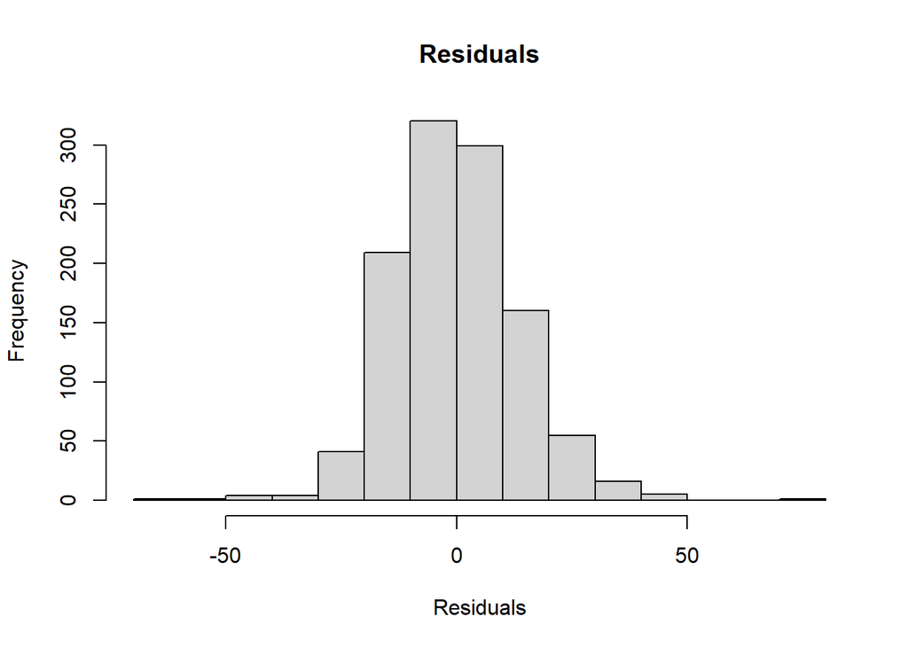

```r
#histogram of resids
hist(res, breaks = 20, main = "Residuals", xlab = "Residuals")
```

##v. table of results

#####tables for nested models

```r
tab_model(mod_b2_nested, mod_bc_nested, mod_oe_nested, mod_healthy)
```

|  | SBP |  |  | SBP |  |  | SBP |  |  | SBP |  |  |
| --- | --- | --- | --- | --- | --- | --- | --- | --- | --- | --- | --- | --- |
| Predictors | Estimates | CI | p | Estimates | CI | p | Estimates | CI | p | Estimates | CI | p |
| (Intercept) | 116.02 | 111.26 – 120.79 | **<0.001** | 100.54 | 89.82 – 111.26 | **<0.001** | 100.14 | 86.26 – 114.03 | **<0.001** | 116.06 | 110.98 – 121.13 | **<0.001** |
| Age years [1st degree] | 42.54 | 32.99 – 52.09 | **<0.001** | 34.85 | 24.31 – 45.39 | **<0.001** | 27.73 | 13.42 – 42.03 | **<0.001** | 30.79 | 20.05 – 41.54 | **<0.001** |
| Age years [2nd degree] | 27.98 | 20.02 – 35.94 | **<0.001** | 21.33 | 12.00 – 30.66 | **<0.001** | 16.59 | 5.10 – 28.09 | **0.005** | 13.13 | 4.60 – 21.67 | **0.003** |
| Sex [Male] | 8.90 | 2.08 – 15.71 | **0.011** | 10.74 | 3.89 – 17.59 | **0.002** | 12.41 | 3.49 – 21.33 | **0.006** | 8.35 | 0.88 – 15.83 | **0.029** |
| Age years [1st degree] × Sex [Male] | 2.76 | -10.77 – 16.30 | 0.689 | -3.06 | -16.95 – 10.83 | 0.666 | -3.46 | -21.84 – 14.91 | 0.712 | -4.11 | -19.63 – 11.42 | 0.604 |
| Age years [2nd degree] × Sex [Male] | 23.01 | 11.54 – 34.48 | **<0.001** | 21.18 | 9.25 – 33.11 | **0.001** | 20.26 | 6.19 – 34.34 | **0.005** | 16.51 | 0.76 – 32.26 | **0.040** |
| Breed [Pedigree] |  |  |  | 4.41 | -1.07 – 9.90 | 0.115 | 4.74 | -1.72 – 11.20 | 0.150 |  |  |  |
| BCS_group31-4 |  |  |  | -2.93 | -6.75 – 0.88 | 0.132 | 0.51 | -4.41 – 5.43 | 0.838 |  |  |  |
| BCS group3 [6] |  |  |  | 2.15 | -0.80 – 5.09 | 0.153 | 2.77 | -1.03 – 6.58 | 0.153 |  |  |  |
| BCS_group37-9 |  |  |  | 5.34 | 2.18 – 8.51 | **0.001** | 5.39 | 1.21 – 9.56 | **0.012** |  |  |  |
| MCS grade None Mild Moderate to Severe [Mild] |  |  |  | 5.48 | 2.97 – 7.99 | **<0.001** | 4.61 | 1.21 – 8.02 | **0.008** |  |  |  |
| MCS grade None Mild Moderate to Severe [Moderate to severe] |  |  |  | 7.57 | 1.69 – 13.46 | **0.012** | 4.59 | -2.71 – 11.88 | 0.217 |  |  |  |
| CKD [Yes] |  |  |  | 4.56 | -0.80 – 9.92 | 0.095 | 3.32 | -2.87 – 9.52 | 0.293 |  |  |  |
| Hyperthyroidism [Yes] |  |  |  | 10.45 | 4.93 – 15.96 | **<0.001** | 14.94 | 7.86 – 22.02 | **<0.001** |  |  |  |
| Neoplasia [Yes] |  |  |  | -18.05 | -29.69 – -6.40 | **0.002** | -4.35 | -19.27 – 10.57 | 0.567 |  |  |  |
| HM group [I-II/VI] |  |  |  | 0.71 | -1.81 – 3.23 | 0.581 | -0.25 | -3.38 – 2.89 | 0.878 |  |  |  |
| HM group [≥III/VI] |  |  |  | -1.56 | -6.60 – 3.48 | 0.544 | -4.22 | -10.16 – 1.73 | 0.164 |  |  |  |
| HR |  |  |  | 0.06 | 0.01 – 0.11 | **0.016** | 0.06 | 0.00 – 0.13 | **0.038** |  |  |  |
| Diabetes mellitus [Yes] |  |  |  | -5.86 | -18.67 – 6.95 | 0.370 | -9.13 | -22.82 – 4.56 | 0.191 |  |  |  |
| Dental disease [Yes] |  |  |  | 1.64 | -0.48 – 3.75 | 0.129 | 0.80 | -2.03 – 3.63 | 0.578 |  |  |  |
| oe abnormality score |  |  |  |  |  |  | 0.54 | 0.04 – 1.04 | **0.035** |  |  |  |
| Random Effects |  |  |  |  |  |  |  |  |  |  |  |  |
| σ<sup>2</sup> | 216.44 |  |  | 208.83 |  |  | 185.58 |  |  | 183.45 |  |  |
| τ<sub>00</sub> | 116.77 <sub>Cat_ID:Owner_ID</sub> |  |  | 97.87 <sub>Cat_ID:Owner_ID</sub> |  |  | 116.93 <sub>Cat_ID:Owner_ID</sub> |  |  | 57.61 <sub>Cat_ID:Owner_ID</sub> |  |  |
|  | 22.07 <sub>Owner_ID</sub> |  |  | 19.36 <sub>Owner_ID</sub> |  |  | 21.05 <sub>Owner_ID</sub> |  |  | 10.25 <sub>Owner_ID</sub> |  |  |
| ICC | 0.39 |  |  | 0.36 |  |  | 0.43 |  |  | 0.27 |  |  |
| N | 203 <sub>Cat_ID</sub> |  |  | 199 <sub>Cat_ID</sub> |  |  | 168 <sub>Cat_ID</sub> |  |  | 170 <sub>Cat_ID</sub> |  |  |
|  | 146 <sub>Owner_ID</sub> |  |  | 143 <sub>Owner_ID</sub> |  |  | 124 <sub>Owner_ID</sub> |  |  | 125 <sub>Owner_ID</sub> |  |  |
| Observations | 1116 |  |  | 1022 |  |  | 561 |  |  | 707 |  |  |
| Marginal R<sup>2</sup> / Conditional R<sup>2</sup> | 0.232 / 0.532 |  |  | 0.285 / 0.542 |  |  | 0.310 / 0.604 |  |  | 0.110 / 0.350 |  |  |

##vi. plot of results

```r
pA2<-plot_model(mod_b2_nested, type = "emm", color = "black", terms = c("Age_years[all]")) +
  xlab("Age (years)") +
  ylab("SBP (mmHg)") +
  ggtitle("A") +
  theme_bw() +
  scale_y_continuous(limits = c(100, 200))
```

```
## NOTE: Results may be misleading due to involvement in interactions
```

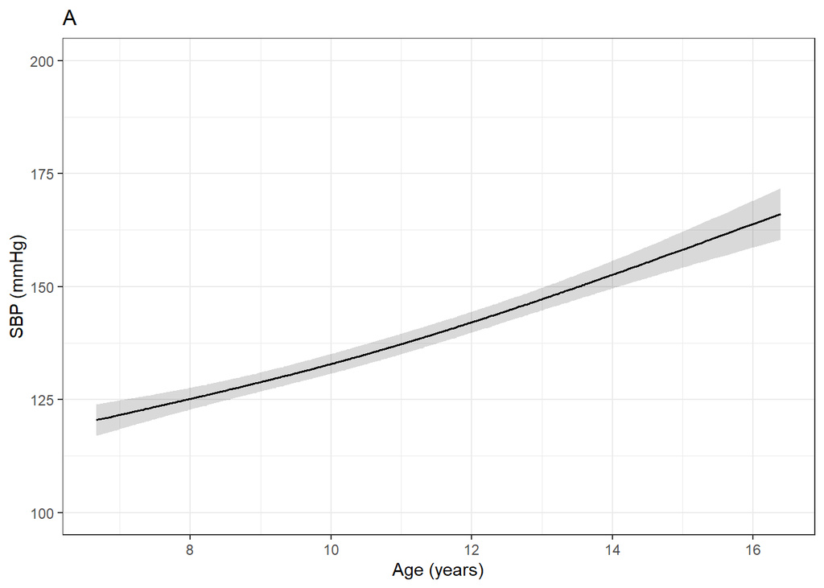

```r
pA2
```

```r
#ggsave("A SBP and age plot_mod1.png", plot= #last_plot(), bg = "white", height =10, width = 10, #units="cm" )

pB2<-plot_model(mod_b2_nested, type="emm",color=c("#00BFC4", "#F8766D"), terms=c("Age_years[all]", "Sex"))+
  xlab("Age (years)")+
  ylab("SBP (mmHg)") +
  ggtitle("B")+
  theme_bw()+
  theme(legend.position = "none")+
  scale_y_continuous(limits = c(100, 200))
```

```
## Some of the focal terms are of type `character`. This may lead to
##   unexpected results. It is recommended to convert these variables to
##   factors before fitting the model.
##   The following variables are of type character: `Sex`
```

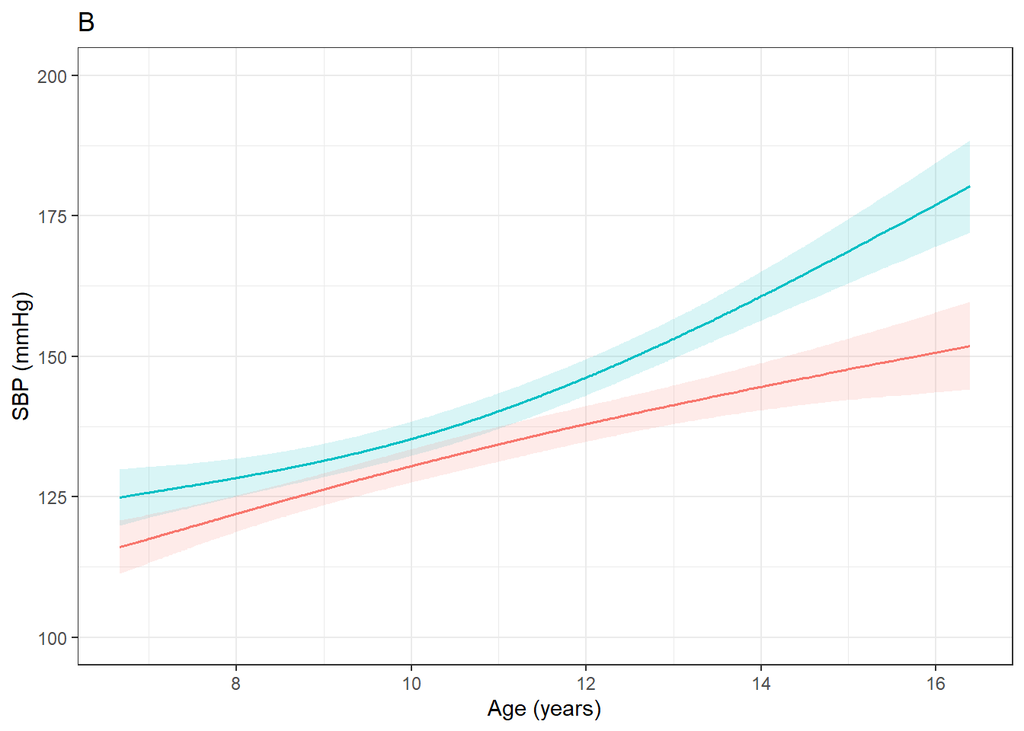

```r
pB2
```

```r
#ggsave("B SBP and sex and age plot_mod1.png", plot= #last_plot(), bg = "white", height =10, width = 13, #units="cm" )

pC2<-plot_model(mod_healthy, type = "emm", color = "black", terms = c("Age_years[all]")) +
  xlab("Age (years)") +
  ylab("SBP (mmHg)") +
  ggtitle("A") +
  theme_bw() +
  scale_y_continuous(limits = c(100, 200))
```

```
## NOTE: Results may be misleading due to involvement in interactions
```

```r
#ggsave("C SBP and age plot_healthy cats only_mod4.png", #plot= last_plot(), bg = "white", height =10, width = #10, #units="cm" )

pD2<-plot_model(mod_healthy, type="emm",color=c("#00BFC4", "#F8766D"), terms=c("Age_years[all]", "Sex"))+
  xlab("Age (years)")+
  ylab("SBP (mmHg)") +
  ggtitle("B")+
  theme_bw()+
  theme(legend.position="none")+
  scale_y_continuous(limits = c(100, 200))
```

```
## Some of the focal terms are of type `character`. This may lead to
##   unexpected results. It is recommended to convert these variables to
##   factors before fitting the model.
##   The following variables are of type character: `Sex`
```

```
## Some of the focal terms are of type `character`. This may lead to
##   unexpected results. It is recommended to convert these variables to
##   factors before fitting the model.
##   The following variables are of type character: `Overall_health_status`
```

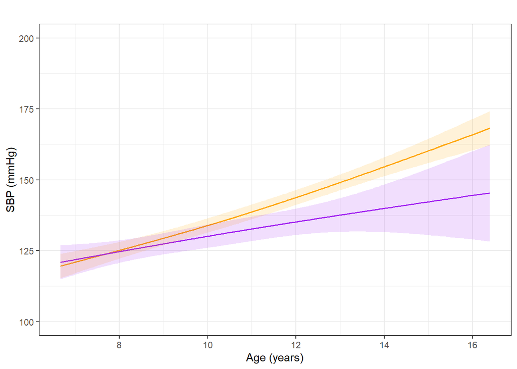

```r
#ggsave("D SBP and sex and age plot_healthy cats #only_mod4.png", plot= last_plot(), bg = "white", height #=10, width = 13, units="cm" )




#patchwork together

plotsA2_B2<-(pA2 | pB2)

#ggsave("plotsA2_B2.png", plot=plotsA2_B2, bg = "white", #height =10, width = 24, units="cm" )

plots_healthy2_bw<-(pC2 | pD2)


#ggsave("plots_healthy2_bw.png", plot=plots_healthy2_bw,

plot_model(mod_int,
           type = "emm",
           color = c("orange", "purple"),
           terms = c("Age_years[all]", "Overall_health_status")) +
  xlab("Age (years)") +
  ylab("SBP (mmHg)") +
  ggtitle("") +
  theme_bw() +
  theme(
    legend.position = "none") +
  scale_y_continuous(limits = c(100, 200))
```

```r
#ggsave("Fig.3.SBP and sex and health plot.png", plot= #last_plot(), bg = "white", height =10, width = 13, #units="cm" )
```

##vii. emmeans

```r
library(emmeans)
em <- emmeans(mod_b2_nested, ~ Age_years,
              at = list(Age_years = c(6,7,8,9, 10, 10.5, 11, 12, 13, 14, 15, 16)),
              re.form = NA)  # Omit random effects (population-level prediction)
```

```
## NOTE: Results may be misleading due to involvement in interactions
```

```r
summary(em)
```

```
##  Age_years emmean   SE  df lower.CL upper.CL
##        6.0    118 2.16 761      114      122
##        7.0    122 1.63 450      118      125
##        8.0    125 1.25 202      123      128
##        9.0    129 1.09 132      127      131
##       10.0    133 1.12 148      131      135
##       10.5    135 1.15 162      133      137
##       11.0    137 1.17 169      135      140
##       12.0    142 1.19 176      140      144
##       13.0    147 1.29 228      145      150
##       14.0    153 1.57 425      150      156
##       15.0    158 2.04 763      154      162
##       16.0    164 2.65 995      159      169
##
## Results are averaged over the levels of: Sex
## Degrees-of-freedom method: kenward-roger
## Confidence level used: 0.95
```

```r
em_sex <- emmeans(mod_b2_nested, ~ Age_years + Sex,
              at = list(Age_years = c(6,7,8,9, 10, 10.5, 11, 12, 13, 14, 15, 16, 17)),
              re.form = NA)  # Omit random effects (population-level prediction)

summary(em_sex)
```

```
##  Age_years Sex    emmean   SE   df lower.CL upper.CL
##        6.0 Female    113 2.95  984      107      119
##        7.0 Female    118 2.21  692      113      122
##        8.0 Female    122 1.66  333      119      125
##        9.0 Female    126 1.46  213      123      129
##       10.0 Female    130 1.52  237      127      133
##       10.5 Female    132 1.57  255      129      136
##       11.0 Female    134 1.60  264      131      137
##       12.0 Female    138 1.63  266      135      141
##       13.0 Female    141 1.77  328      138      145
##       14.0 Female    145 2.15  561      140      149
##       15.0 Female    148 2.80  893      142      153
##       16.0 Female    151 3.64 1064      144      158
##       17.0 Female    154 4.57 1099      145      163
##        6.0 Male      123 3.09  977      117      129
##        7.0 Male      126 2.33  676      121      130
##        8.0 Male      128 1.76  319      125      132
##        9.0 Male      131 1.54  193      128      134
##       10.0 Male      135 1.57  203      132      138
##       10.5 Male      138 1.61  216      134      141
##       11.0 Male      140 1.63  222      137      143
##       12.0 Male      146 1.67  228      143      150
##       13.0 Male      153 1.82  299      150      157
##       14.0 Male      161 2.24  549      156      165
##       15.0 Male      169 2.93  895      163      174
##       16.0 Male      177 3.82 1061      169      184
##       17.0 Male      185 4.79 1092      176      195
##
## Degrees-of-freedom method: kenward-roger
## Confidence level used: 0.95
```

```r
em_healthy <- emmeans(mod_healthy, ~ Age_years,
              at = list(Age_years = c(6,7,8,9, 10, 10.5, 11, 12, 13, 14, 15, 16, 17)),
              re.form = NA)  # Omit random effects (population-level prediction)
```

```
## NOTE: Results may be misleading due to involvement in interactions
```

```r
summary(em_healthy )
```

```
##  Age_years emmean    SE  df lower.CL upper.CL
##        6.0    118 2.470 626      113      123
##        7.0    121 1.700 462      118      125
##        8.0    124 1.140 195      122      127
##        9.0    127 0.972 124      126      129
##       10.0    131 1.040 157      129      133
##       10.5    132 1.060 165      130      134
##       11.0    134 1.070 168      131      136
##       12.0    137 1.210 234      134      139
##       13.0    139 1.690 473      136      143
##       14.0    142 2.480 656      137      147
##       15.0    145 3.460 696      138      152
##       16.0    148 4.510 700      139      157
##       17.0    151 5.590 697      140      162
##
## Results are averaged over the levels of: Sex
## Degrees-of-freedom method: kenward-roger
## Confidence level used: 0.95
```

```r
em_healthy_sex <- emmeans(mod_healthy, ~ Age_years + Sex,
              at = list(Age_years = c(6,7,8,9, 10, 10.5, 11, 12, 13, 14, 15, 16, 17)),
              re.form = NA)  # Omit random effects (population-level prediction)

summary(em_healthy_sex)
```

```
##  Age_years Sex    emmean   SE  df lower.CL upper.CL
##        6.0 Female    113 3.29 671      107      119
##        7.0 Female    118 2.29 561      113      122
##        8.0 Female    122 1.53 290      119      125
##        9.0 Female    126 1.30 185      123      129
##       10.0 Female    129 1.40 226      127      132
##       10.5 Female    131 1.44 236      128      133
##       11.0 Female    132 1.46 232      129      135
##       12.0 Female    134 1.55 243      130      137
##       13.0 Female    135 1.93 384      131      139
##       14.0 Female    135 2.70 592      130      141
##       15.0 Female    136 3.72 682      129      143
##       16.0 Female    136 4.85 700      127      146
##       17.0 Female    137 6.02 700      125      149
##        6.0 Male      123 3.64 689      116      130
##        7.0 Male      125 2.48 595      120      130
##        8.0 Male      127 1.63 299      124      130
##        9.0 Male      129 1.40 185      126      132
##       10.0 Male      132 1.50 211      129      135
##       10.5 Male      133 1.52 209      130      136
##       11.0 Male      135 1.54 207      132      138
##       12.0 Male      140 1.85 313      136      143
##       13.0 Male      144 2.76 582      139      150
##       14.0 Male      149 4.16 688      141      157
##       15.0 Male      155 5.83 700      143      166
##       16.0 Male      160 7.61 698      145      175
##       17.0 Male      165 9.41 695      147      184
##
## Degrees-of-freedom method: kenward-roger
## Confidence level used: 0.95
```

##viii. sample sizes per model

```r
#for visit numbers
tbl_regression(mod_bc_nested, exp=T)%>%add_n(location="level")
```

| **Characteristic** | **N** | **exp(Beta)** | **95% CI** |
| --- | --- | --- | --- |
| ns(Age_years, df = 2) | 1,022 |  |  |
| ns(Age_years, df = 2)1 | 1,021 | 1,363,588,925,815,864 | 36,524,752,497, 50,907,251,425,394,868,224 |
| ns(Age_years, df = 2)2 | 166 | 1,835,534,072 | 164,073, 20,534,617,968,326 |
| Sex |  |  |  |
| Female | 515 | — | — |
| Male | 507 | 46,045 | 49.2, 43,084,475 |
| Breed |  |  |  |
| Non-pedigree | 878 | — | — |
| Pedigree | 144 | 82.6 | 0.34, 19,840 |
| BCS_group3 |  |  |  |
| 5 | 289 | — | — |
| 1-4 | 128 | 0.05 | 0.00, 2.40 |
| 6 | 244 | 8.57 | 0.45, 163 |
| 7-9 | 361 | 210 | 8.88, 4,944 |
| MCS_grade_None_Mild_Moderate_to_Severe |  |  |  |
| None | 491 | — | — |
| Mild | 478 | 240 | 19.6, 2,929 |
| Moderate to severe | 53 | 1,948 | 5.48, 692,745 |
| CKD |  |  |  |
| No | 934 | — | — |
| Yes | 88 | 95.6 | 0.45, 20,143 |
| Hyperthyroidism |  |  |  |
| No | 963 | — | — |
| Yes | 59 | 34,419 | 139, 8,496,405 |
| Neoplasia |  |  |  |
| No | 1,014 | — | — |
| Yes | 8 | 0.00 | 0.00, 0.00 |
| HM_group |  |  |  |
| None | 727 | — | — |
| I-II/VI | 237 | 2.03 | 0.16, 25.2 |
| ≥III/VI | 58 | 0.21 | 0.00, 32.4 |
| HR | 1,022 | 1.06 | 1.01, 1.12 |
| Diabetes_mellitus |  |  |  |
| No | 1,015 | — | — |
| Yes | 7 | 0.00 | 0.00, 1,030 |
| Dental_disease |  |  |  |
| No | 437 | — | — |
| Yes | 585 | 5.15 | 0.62, 42.6 |
| ns(Age_years, df = 2) * Sex | 1,022 |  |  |
| ns(Age_years, df = 2)1 * Male | 507 | 0.05 | 0.00, 49,820 |
| ns(Age_years, df = 2)2 * Male | 81 | 1,576,181,670 | 10,547, 235,554,524,177,181 |

Abbreviation: CI = Confidence Interval

```r
tbl_regression(mod_oe_nested, exp=T)%>%add_n(location="level")
```

| **Characteristic** | **N** | **exp(Beta)** | **95% CI** |
| --- | --- | --- | --- |
| ns(Age_years, df = 2) | 561 |  |  |
| ns(Age_years, df = 2)1 | 560 | 1,100,012,758,410 | 694,386, 1,742,586,585,596,270,592 |
| ns(Age_years, df = 2)2 | 128 | 16,100,230 | 169, 1,536,373,707,729 |
| Sex |  |  |  |
| Female | 258 | — | — |
| Male | 303 | 245,305 | 33.5, 1,796,877,620 |
| Breed |  |  |  |
| Non-pedigree | 479 | — | — |
| Pedigree | 82 | 114 | 0.18, 71,956 |
| BCS_group3 |  |  |  |
| 5 | 163 | — | — |
| 1-4 | 82 | 1.67 | 0.01, 225 |
| 6 | 138 | 16.0 | 0.36, 717 |
| 7-9 | 178 | 218 | 3.39, 14,020 |
| MCS_grade_None_Mild_Moderate_to_Severe |  |  |  |
| None | 226 | — | — |
| Mild | 293 | 101 | 3.38, 3,003 |
| Moderate to severe | 42 | 98.1 | 0.07, 142,044 |
| CKD |  |  |  |
| No | 497 | — | — |
| Yes | 64 | 27.8 | 0.06, 13,457 |
| Hyperthyroidism |  |  |  |
| No | 524 | — | — |
| Yes | 37 | 3,076,379 | 2,632, 3,596,366,249 |
| Neoplasia |  |  |  |
| No | 556 | — | — |
| Yes | 5 | 0.01 | 0.00, 37,831 |
| HM_group |  |  |  |
| None | 365 | — | — |
| I-II/VI | 157 | 0.78 | 0.03, 17.9 |
| ≥III/VI | 39 | 0.01 | 0.00, 5.55 |
| HR | 561 | 1.07 | 1.00, 1.13 |
| Diabetes_mellitus |  |  |  |
| No | 555 | — | — |
| Yes | 6 | 0.00 | 0.00, 92.9 |
| Dental_disease |  |  |  |
| No | 227 | — | — |
| Yes | 334 | 2.23 | 0.13, 37.6 |
| oe.abnormality_score | 561 | 1.71 | 1.04, 2.82 |
| ns(Age_years, df = 2) * Sex | 561 |  |  |
| ns(Age_years, df = 2)1 * Male | 303 | 0.03 | 0.00, 2,880,476 |
| ns(Age_years, df = 2)2 * Male | 63 | 632,232,023 | 502, 796,760,416,776,530 |

Abbreviation: CI = Confidence Interval

```r
tbl_regression(mod_healthy, exp=T)%>%add_n(location="level")
```

| **Characteristic** | **N** | **exp(Beta)** | **95% CI** |
| --- | --- | --- | --- |
| ns(Age_years, df = 2) | 707 |  |  |
| ns(Age_years, df = 2)1 | 706 | 23,659,402,558,059 | 520,237,007, 1,075,985,219,039,232,000 |
| ns(Age_years, df = 2)2 | 97 | 504,225 | 100, 2,530,361,893 |
| Sex |  |  |  |
| Female | 380 | — | — |
| Male | 327 | 4,241 | 2.44, 7,365,887 |
| ns(Age_years, df = 2) * Sex | 707 |  |  |
| ns(Age_years, df = 2)1 * Male | 327 | 0.02 | 0.00, 88,357 |
| ns(Age_years, df = 2)2 * Male | 35 | 14,791,329 | 2.20, 99,635,298,990,259 |

Abbreviation: CI = Confidence Interval

```r
#for cat numbers?
#check N per disease in this model
Metadata_mod_bc_nested<- Metadata_SBP2 %>%
  select(Cat_ID, Cat_ID_timepoint, Sex, BCS_group3, CKD, Hyperthyroidism,
         Hypertension, Neoplasia, HM_group, Diabetes_mellitus,
         Dental_disease, HR, Breed, MCS_grade_None_Mild_Moderate_to_Severe)
#remove NAs
Metadata_mod_bc_nested<-na.omit(Metadata_mod_bc_nested)

distinct_cats_per_covariate_mod_bc_nested <- Metadata_mod_bc_nested %>%
  summarise(
    BCS5=n_distinct(Cat_ID[BCS_group3== "5"]),
     BCS14=n_distinct(Cat_ID[BCS_group3== "1-4"]),
     BCS6=n_distinct(Cat_ID[BCS_group3== "6"]),
     BCS79=n_distinct(Cat_ID[BCS_group3== "7-9"]),
     MCS3=n_distinct(Cat_ID[MCS_grade_None_Mild_Moderate_to_Severe== "None"]),
    MCS2=n_distinct(Cat_ID[MCS_grade_None_Mild_Moderate_to_Severe== "Mild"]),
    MCS01=n_distinct(Cat_ID[MCS_grade_None_Mild_Moderate_to_Severe== "Moderate to severe"]),
    CKD = n_distinct(Cat_ID[CKD == "Yes"]),
    Hyperthyroidism = n_distinct(Cat_ID[Hyperthyroidism == "Yes"]),
    Hypertension = n_distinct(Cat_ID[Hypertension == "Yes"]),
    Neoplasia = n_distinct(Cat_ID[Neoplasia == "Yes"]),
    HM_group0 = n_distinct(Cat_ID[HM_group == "None"]),
    HM_group12 = n_distinct(Cat_ID[HM_group  == "I-II/VI"]),
    HM_group3 = n_distinct(Cat_ID[HM_group  == "≥III/VI"]),
    Diabetes_mellitus = n_distinct(Cat_ID[Diabetes_mellitus == "Yes"]),
    Dental_disease = n_distinct(Cat_ID[Dental_disease == "Yes"]),
     Sex = n_distinct(Cat_ID[Sex == "Male"]),
    Breed_ped=n_distinct(Cat_ID[Breed =="Pedigree"])
  )

#Print the number of distinct cats that meet the conditions
print(distinct_cats_per_covariate_mod_bc_nested)
```

```
##   BCS5 BCS14 BCS6 BCS79 MCS3 MCS2 MCS01 CKD Hyperthyroidism Hypertension
## 1  102    63   98   102  167  152    37  22              18           51
##   Neoplasia HM_group0 HM_group12 HM_group3 Diabetes_mellitus Dental_disease Sex
## 1         7       176        113        26                 4            166  95
##   Breed_ped
## 1        28
```

####and for mod_oe

```r
#for cat numbers?
#check N per disease in this model
Metadata_mod_oe_nested<- Metadata_SBP2 %>%
  select(Cat_ID, Cat_ID_timepoint, Sex, BCS_group3, CKD, Hyperthyroidism,
         Hypertension, Neoplasia, HM_group, Diabetes_mellitus,
         Dental_disease, HR, Breed, MCS_grade_None_Mild_Moderate_to_Severe, oe.abnormality_score)
#remove NAs
Metadata_mod_oe_nested<-na.omit(Metadata_mod_oe_nested)

distinct_cats_per_covariate_mod_oe_nested <- Metadata_mod_oe_nested %>%
  summarise(
    BCS5=n_distinct(Cat_ID[BCS_group3== "5"]),
     BCS14=n_distinct(Cat_ID[BCS_group3== "1-4"]),
     BCS6=n_distinct(Cat_ID[BCS_group3== "6"]),
     BCS79=n_distinct(Cat_ID[BCS_group3== "7-9"]),
     MCS3=n_distinct(Cat_ID[MCS_grade_None_Mild_Moderate_to_Severe== "None"]),
    MCS2=n_distinct(Cat_ID[MCS_grade_None_Mild_Moderate_to_Severe== "Mild"]),
    MCS01=n_distinct(Cat_ID[MCS_grade_None_Mild_Moderate_to_Severe== "Moderate to severe"]),
    CKD = n_distinct(Cat_ID[CKD == "Yes"]),
    Hyperthyroidism = n_distinct(Cat_ID[Hyperthyroidism == "Yes"]),
    Hypertension = n_distinct(Cat_ID[Hypertension == "Yes"]),
    Neoplasia = n_distinct(Cat_ID[Neoplasia == "Yes"]),
    HM_group0 = n_distinct(Cat_ID[HM_group == "None"]),
    HM_group12 = n_distinct(Cat_ID[HM_group  == "I-II/VI"]),
    HM_group3 = n_distinct(Cat_ID[HM_group  == "≥III/VI"]),
    Diabetes_mellitus = n_distinct(Cat_ID[Diabetes_mellitus == "Yes"]),
    Dental_disease = n_distinct(Cat_ID[Dental_disease == "Yes"]),
     Sex = n_distinct(Cat_ID[Sex == "Male"]),
    Breed_ped=n_distinct(Cat_ID[Breed =="Pedigree"])
  )

#Print the number of distinct cats that meet the conditions
print(distinct_cats_per_covariate_mod_oe_nested)
```

```
##   BCS5 BCS14 BCS6 BCS79 MCS3 MCS2 MCS01 CKD Hyperthyroidism Hypertension
## 1   72    52   71    73  120  122    30  19              16           38
##   Neoplasia HM_group0 HM_group12 HM_group3 Diabetes_mellitus Dental_disease Sex
## 1         4       137         92        23                 3            130  85
##   Breed_ped
## 1        26
```

#####and for healthy

```r
#for cat numbers?
#check N per disease in this model
Metadata_mod_healthy<- Metadata_SBP2 %>%
  filter(Healthy_visit=="Yes")%>%
  select(Cat_ID, Cat_ID_timepoint, Sex, Age_years)
#remove NAs
Metadata_mod_healthy<-na.omit(Metadata_mod_healthy)

distinct_cats_per_covariate_mod_healthy<- Metadata_mod_healthy %>%
  summarise(
     SexM = n_distinct(Cat_ID[Sex == "Male"]),
     SexF = n_distinct(Cat_ID[Sex == "Female"]),
  )

#Print the number of distinct cats that meet the conditions
print(distinct_cats_per_covariate_mod_healthy)
```

```
##   SexM SexF
## 1   79   91
```

```r
dim(Metadata_mod_healthy)
```

```
## [1] 707   4
```

#7. model visits where SBP >=160mmHg ##a. binomial model of hypertension

```r
Metadata_SBP2$Hypertension<-as.factor(Metadata_SBP2$Hypertension)

#full model

mod_ht<-glmer(Hypertension ~ Age_years + Sex + Breed + BCS_group3 + MCS_grade_None_Mild_Moderate_to_Severe + CKD + Hyperthyroidism + Neoplasia + Diabetes_mellitus + HM_group + Dental_disease + (1|Cat_ID), data= Metadata_SBP2, family=binomial)
#
summary(mod_ht)
```

```
## Generalized linear mixed model fit by maximum likelihood (Laplace
##   Approximation) [glmerMod]
##  Family: binomial  ( logit )
## Formula:
## Hypertension ~ Age_years + Sex + Breed + BCS_group3 + MCS_grade_None_Mild_Moderate_to_Severe +
##     CKD + Hyperthyroidism + Neoplasia + Diabetes_mellitus + HM_group +
##     Dental_disease + (1 | Cat_ID)
##    Data: Metadata_SBP2
##
##       AIC       BIC    logLik -2*log(L)  df.resid
##     506.1     590.0    -236.0     472.1      1010
##
## Scaled residuals:
##    Min     1Q Median     3Q    Max
## -3.085 -0.129 -0.036 -0.011 64.859
##
## Random effects:
##  Groups Name        Variance Std.Dev.
##  Cat_ID (Intercept) 13.16    3.628
## Number of obs: 1027, groups:  Cat_ID, 200
##
## Fixed effects:
##                                                            Estimate Std. Error
## (Intercept)                                              -1.639e+01  1.700e+00
## Age_years                                                 8.132e-01  1.286e-01
## SexMale                                                   2.349e+00  9.079e-01
## BreedPedigree                                            -5.787e-01  1.287e+00
## BCS_group31-4                                             1.112e+00  7.307e-01
## BCS_group36                                              -8.250e-01  6.376e-01
## BCS_group37-9                                             7.457e-01  6.442e-01
## MCS_grade_None_Mild_Moderate_to_SevereMild                1.029e+00  4.810e-01
## MCS_grade_None_Mild_Moderate_to_SevereModerate to severe  1.133e+00  8.801e-01
## CKDYes                                                    1.047e+00  8.966e-01
## HyperthyroidismYes                                        2.239e+00  1.015e+00
## NeoplasiaYes                                             -9.846e+01  2.373e+07
## Diabetes_mellitusYes                                      1.371e+00  2.333e+00
## HM_groupI-II/VI                                           4.619e-01  4.397e-01
## HM_group≥III/VI                                          -1.147e+00  1.039e+00
## Dental_diseaseYes                                         5.083e-01  3.814e-01
##                                                          z value Pr(>|z|)
## (Intercept)                                               -9.645  < 2e-16 ***
## Age_years                                                  6.322 2.58e-10 ***
## SexMale                                                    2.587  0.00968 **
## BreedPedigree                                             -0.450  0.65294
## BCS_group31-4                                              1.522  0.12799
## BCS_group36                                               -1.294  0.19571
## BCS_group37-9                                              1.158  0.24704
## MCS_grade_None_Mild_Moderate_to_SevereMild                 2.140  0.03239 *
## MCS_grade_None_Mild_Moderate_to_SevereModerate to severe   1.287  0.19805
## CKDYes                                                     1.167  0.24307
## HyperthyroidismYes                                         2.206  0.02741 *
## NeoplasiaYes                                               0.000  1.00000
## Diabetes_mellitusYes                                       0.588  0.55671
## HM_groupI-II/VI                                            1.051  0.29348
## HM_group≥III/VI                                           -1.103  0.26985
## Dental_diseaseYes                                          1.333  0.18260
## ---
## Signif. codes:  0 '***' 0.001 '**' 0.01 '*' 0.05 '.' 0.1 ' ' 1
```

```
##
## Correlation matrix not shown by default, as p = 16 > 12.
## Use print(x, correlation=TRUE)  or
##     vcov(x)        if you need it
```

```
## optimizer (Nelder_Mead) convergence code: 4 (failure to converge in 10000 evaluations)
## unable to evaluate scaled gradient
##  Hessian is numerically singular: parameters are not uniquely determined
## failure to converge in 10000 evaluations
```

```r
tab_model(mod_ht)
```

|  | Hypertension |  |  |
| --- | --- | --- | --- |
| Predictors | Odds Ratios | CI | p |
| (Intercept) | 0.00 | 0.00 – 0.00 | **<0.001** |
| Age years | 2.26 | 1.75 – 2.90 | **<0.001** |
| Sex [Male] | 10.47 | 1.77 – 62.06 | **0.010** |
| Breed [Pedigree] | 0.56 | 0.05 – 6.98 | 0.653 |
| BCS_group31-4 | 3.04 | 0.73 – 12.74 | 0.128 |
| BCS group3 [6] | 0.44 | 0.13 – 1.53 | 0.196 |
| BCS_group37-9 | 2.11 | 0.60 – 7.45 | 0.247 |
| MCS grade None Mild Moderate to Severe [Mild] | 2.80 | 1.09 – 7.18 | **0.032** |
| MCS grade None Mild Moderate to Severe [Moderate to severe] | 3.10 | 0.55 – 17.42 | 0.198 |
| CKD [Yes] | 2.85 | 0.49 – 16.51 | 0.243 |
| Hyperthyroidism [Yes] | 9.38 | 1.28 – 68.60 | **0.027** |
| Neoplasia [Yes] | 0.00 | 0.00 – Inf | 1.000 |
| Diabetes mellitus [Yes] | 3.94 | 0.04 – 381.44 | 0.557 |
| HM group [I-II/VI] | 1.59 | 0.67 – 3.76 | 0.293 |
| HM group [≥III/VI] | 0.32 | 0.04 – 2.44 | 0.270 |
| Dental disease [Yes] | 1.66 | 0.79 – 3.51 | 0.183 |
| Random Effects |  |  |  |
| σ<sup>2</sup> | 3.29 |  |  |
| τ<sub>00</sub> <sub>Cat_ID</sub> | 13.16 |  |  |
| ICC | 0.80 |  |  |
| N <sub>Cat_ID</sub> | 200 |  |  |
| Observations | 1027 |  |  |
| Marginal R<sup>2</sup> / Conditional R<sup>2</sup> | 0.825 / 0.965 |  |  |

```r
tbl_regression(mod_ht, exp=T)%>% add_n(location="level")
```

| **Characteristic** | **N** | **OR** | **95% CI** | **p-value** |
| --- | --- | --- | --- | --- |
| Age_years | 1,027 | 2.26 | 1.75, 2.90 | <0.001 |
| Sex |  |  |  |  |
| Female | 515 | — | — |  |
| Male | 512 | 10.5 | 1.77, 62.1 | 0.010 |
| Breed |  |  |  |  |
| Non-pedigree | 882 | — | — |  |
| Pedigree | 145 | 0.56 | 0.05, 6.98 | 0.7 |
| BCS_group3 |  |  |  |  |
| 5 | 289 | — | — |  |
| 1-4 | 128 | 3.04 | 0.73, 12.7 | 0.13 |
| 6 | 245 | 0.44 | 0.13, 1.53 | 0.2 |
| 7-9 | 365 | 2.11 | 0.60, 7.45 | 0.2 |
| MCS_grade_None_Mild_Moderate_to_Severe |  |  |  |  |
| None | 495 | — | — |  |
| Mild | 479 | 2.80 | 1.09, 7.18 | 0.032 |
| Moderate to severe | 53 | 3.10 | 0.55, 17.4 | 0.2 |
| CKD |  |  |  |  |
| No | 939 | — | — |  |
| Yes | 88 | 2.85 | 0.49, 16.5 | 0.2 |
| Hyperthyroidism |  |  |  |  |
| No | 968 | — | — |  |
| Yes | 59 | 9.38 | 1.28, 68.6 | 0.027 |
| Neoplasia |  |  |  |  |
| No | 1,019 | — | — |  |
| Yes | 8 | 0.00 | 0.00, Inf | >0.9 |
| Diabetes_mellitus |  |  |  |  |
| No | 1,020 | — | — |  |
| Yes | 7 | 3.94 | 0.04, 381 | 0.6 |
| HM_group |  |  |  |  |
| None | 730 | — | — |  |
| I-II/VI | 238 | 1.59 | 0.67, 3.76 | 0.3 |
| ≥III/VI | 59 | 0.32 | 0.04, 2.44 | 0.3 |
| Dental_disease |  |  |  |  |
| No | 438 | — | — |  |
| Yes | 589 | 1.66 | 0.79, 3.51 | 0.2 |

Abbreviations: CI = Confidence Interval, OR = Odds Ratio

```r
####model fails to converge? neoplasia infinite

#remove neoplasia and diabetic cases as too few samples
Metadata_SBP_nodmorneo<- Metadata_SBP2 %>%
  filter(Diabetes_mellitus != "Yes")

Metadata_SBP_nodmorneo<- Metadata_SBP_nodmorneo %>%
  filter(Neoplasia != "Yes")

#re-run model

mod_ht<-glmer(Hypertension ~ Age_years + Sex + Breed + HR + BCS_group3 + MCS_grade_None_Mild_Moderate_to_Severe + CKD + Hyperthyroidism + HM_group + Dental_disease + (1|Cat_ID), data= Metadata_SBP_nodmorneo, family=binomial) #failed to converge
mod_ht<-glmer(Hypertension ~ Age_years + Sex + BCS_group3 + MCS_grade_None_Mild_Moderate_to_Severe + CKD + Hyperthyroidism + Heart_murmur+ Dental_disease + (1|Cat_ID), data= Metadata_SBP_nodmorneo, family=binomial) #failed to converge
#
summary(mod_ht)
```

```
## Generalized linear mixed model fit by maximum likelihood (Laplace
##   Approximation) [glmerMod]
##  Family: binomial  ( logit )
## Formula:
## Hypertension ~ Age_years + Sex + BCS_group3 + MCS_grade_None_Mild_Moderate_to_Severe +
##     CKD + Hyperthyroidism + Heart_murmur + Dental_disease + (1 |      Cat_ID)
##    Data: Metadata_SBP_nodmorneo
##
##       AIC       BIC    logLik -2*log(L)  df.resid
##     497.7     561.6    -235.8     471.7      1000
##
## Scaled residuals:
##    Min     1Q Median     3Q    Max
## -3.258 -0.143 -0.045 -0.016 45.917
##
## Random effects:
##  Groups Name        Variance Std.Dev.
##  Cat_ID (Intercept) 10.58    3.253
## Number of obs: 1013, groups:  Cat_ID, 198
##
## Fixed effects:
##                                                          Estimate Std. Error
## (Intercept)                                              -15.6214     1.8368
## Age_years                                                  0.8215     0.1318
## SexMale                                                    1.8650     0.7060
## BCS_group31-4                                              0.5239     0.6473
## BCS_group36                                               -0.9111     0.5907
## BCS_group37-9                                              0.6299     0.5685
## MCS_grade_None_Mild_Moderate_to_SevereMild                 0.8897     0.4391
## MCS_grade_None_Mild_Moderate_to_SevereModerate to severe   0.7935     0.8192
## CKDYes                                                     0.7927     0.8234
## HyperthyroidismYes                                         1.7879     0.8920
## Heart_murmurYes                                            0.2784     0.4086
## Dental_diseaseYes                                          0.4194     0.3565
##                                                          z value Pr(>|z|)
## (Intercept)                                               -8.505  < 2e-16 ***
## Age_years                                                  6.234 4.54e-10 ***
## SexMale                                                    2.642  0.00825 **
## BCS_group31-4                                              0.809  0.41824
## BCS_group36                                               -1.542  0.12298
```

[output cut: 22 more lines]

[output not shown]

```r
tab_model(mod_ht)
```

|  | Hypertension |  |  |
| --- | --- | --- | --- |
| Predictors | Odds Ratios | CI | p |
| (Intercept) | 0.00 | 0.00 – 0.00 | **<0.001** |
| Age years | 2.27 | 1.76 – 2.94 | **<0.001** |
| Sex [Male] | 6.46 | 1.62 – 25.76 | **0.008** |
| BCS_group31-4 | 1.69 | 0.47 – 6.00 | 0.418 |
| BCS group3 [6] | 0.40 | 0.13 – 1.28 | 0.123 |
| BCS_group37-9 | 1.88 | 0.62 – 5.72 | 0.268 |
| MCS grade None Mild Moderate to Severe [Mild] | 2.43 | 1.03 – 5.76 | **0.043** |
| MCS grade None Mild Moderate to Severe [Moderate to severe] | 2.21 | 0.44 – 11.01 | 0.333 |
| CKD [Yes] | 2.21 | 0.44 – 11.10 | 0.336 |
| Hyperthyroidism [Yes] | 5.98 | 1.04 – 34.34 | **0.045** |
| Heart murmur [Yes] | 1.32 | 0.59 – 2.94 | 0.496 |
| Dental disease [Yes] | 1.52 | 0.76 – 3.06 | 0.239 |
| Random Effects |  |  |  |
| σ<sup>2</sup> | 3.29 |  |  |
| τ<sub>00</sub> <sub>Cat_ID</sub> | 10.58 |  |  |
| ICC | 0.76 |  |  |
| N <sub>Cat_ID</sub> | 198 |  |  |
| Observations | 1013 |  |  |
| Marginal R<sup>2</sup> / Conditional R<sup>2</sup> | 0.308 / 0.836 |  |  |

```r
tbl_regression(mod_ht, exp=T)%>% add_n(location="level")
```

| **Characteristic** | **N** | **OR** | **95% CI** | **p-value** |
| --- | --- | --- | --- | --- |
| Age_years | 1,013 | 2.27 | 1.76, 2.94 | <0.001 |
| Sex |  |  |  |  |
| Female | 513 | — | — |  |
| Male | 500 | 6.46 | 1.62, 25.8 | 0.008 |
| BCS_group3 |  |  |  |  |
| 5 | 289 | — | — |  |
| 1-4 | 121 | 1.69 | 0.47, 6.00 | 0.4 |
| 6 | 244 | 0.40 | 0.13, 1.28 | 0.12 |
| 7-9 | 359 | 1.88 | 0.62, 5.72 | 0.3 |
| MCS_grade_None_Mild_Moderate_to_Severe |  |  |  |  |
| None | 492 | — | — |  |
| Mild | 473 | 2.43 | 1.03, 5.76 | 0.043 |
| Moderate to severe | 48 | 2.21 | 0.44, 11.0 | 0.3 |
| CKD |  |  |  |  |
| No | 927 | — | — |  |
| Yes | 86 | 2.21 | 0.44, 11.1 | 0.3 |
| Hyperthyroidism |  |  |  |  |
| No | 954 | — | — |  |
| Yes | 59 | 5.98 | 1.04, 34.3 | 0.045 |
| Heart_murmur |  |  |  |  |
| No | 710 | — | — |  |
| Yes | 303 | 1.32 | 0.59, 2.94 | 0.5 |
| Dental_disease |  |  |  |  |
| No | 435 | — | — |  |
| Yes | 578 | 1.52 | 0.76, 3.06 | 0.2 |

Abbreviations: CI = Confidence Interval, OR = Odds Ratio

```r
mod_ht<-glmer(Hypertension ~ Age_years + Sex + Breed + HR + BCS_group3 + MCS_grade_None_Mild_Moderate_to_Severe + CKD + Hyperthyroidism + HM_group + Dental_disease + (1|Cat_ID), data= Metadata_SBP_nodmorneo, family=binomial) #failed to converge
#
summary(mod_ht)
```

```
## Generalized linear mixed model fit by maximum likelihood (Laplace
##   Approximation) [glmerMod]
##  Family: binomial  ( logit )
## Formula:
## Hypertension ~ Age_years + Sex + Breed + HR + BCS_group3 + MCS_grade_None_Mild_Moderate_to_Severe +
##     CKD + Hyperthyroidism + HM_group + Dental_disease + (1 |      Cat_ID)
##    Data: Metadata_SBP_nodmorneo
##
##       AIC       BIC    logLik -2*log(L)  df.resid
##     499.5     578.2    -233.8     467.5       991
##
## Scaled residuals:
##    Min     1Q Median     3Q    Max
## -3.214 -0.152 -0.049 -0.018 33.271
##
## Random effects:
##  Groups Name        Variance Std.Dev.
##  Cat_ID (Intercept) 9.471    3.077
## Number of obs: 1007, groups:  Cat_ID, 197
##
## Fixed effects:
##                                                            Estimate Std. Error
## (Intercept)                                              -16.964511   2.384302
## Age_years                                                  0.779253   0.128520
## SexMale                                                    2.004991   0.700102
## BreedPedigree                                             -0.219160   0.988027
## HR                                                         0.010582   0.007868
## BCS_group31-4                                              0.488782   0.640545
## BCS_group36                                               -0.916622   0.585142
## BCS_group37-9                                              0.619910   0.558279
## MCS_grade_None_Mild_Moderate_to_SevereMild                 0.974274   0.439339
## MCS_grade_None_Mild_Moderate_to_SevereModerate to severe   0.975043   0.821672
## CKDYes                                                     0.857886   0.798254
## HyperthyroidismYes                                         1.952836   0.887046
## HM_groupI-II/VI                                            0.222692   0.396859
## HM_group≥III/VI                                           -1.094163   0.907304
## Dental_diseaseYes                                          0.362913   0.351343
##                                                          z value Pr(>|z|)
## (Intercept)                                               -7.115 1.12e-12 ***
## Age_years                                                  6.063 1.33e-09 ***
## SexMale                                                    2.864  0.00419 **
## BreedPedigree                                             -0.222  0.82446
## HR                                                         1.345  0.17864
## BCS_group31-4                                              0.763  0.44542
## BCS_group36                                               -1.566  0.11723
## BCS_group37-9                                              1.110  0.26683
## MCS_grade_None_Mild_Moderate_to_SevereMild                 2.218  0.02658 *
## MCS_grade_None_Mild_Moderate_to_SevereModerate to severe   1.187  0.23536
## CKDYes                                                     1.075  0.28251
## HyperthyroidismYes                                         2.202  0.02770 *
## HM_groupI-II/VI                                            0.561  0.57470
## HM_group≥III/VI                                           -1.206  0.22784
## Dental_diseaseYes                                          1.033  0.30164
## ---
## Signif. codes:  0 '***' 0.001 '**' 0.01 '*' 0.05 '.' 0.1 ' ' 1
```

```
##
## Correlation matrix not shown by default, as p = 15 > 12.
## Use print(x, correlation=TRUE)  or
##     vcov(x)        if you need it
```

```
## optimizer (Nelder_Mead) convergence code: 0 (OK)
## Model failed to converge with max|grad| = 2.30333 (tol = 0.002, component 1)
## Model is nearly unidentifiable: large eigenvalue ratio
##  - Rescale variables?
```

```r
tab_model(mod_ht)
```

|  | Hypertension |  |  |
| --- | --- | --- | --- |
| Predictors | Odds Ratios | CI | p |
| (Intercept) | 0.00 | 0.00 – 0.00 | **<0.001** |
| Age years | 2.18 | 1.69 – 2.80 | **<0.001** |
| Sex [Male] | 7.43 | 1.88 – 29.29 | **0.004** |
| Breed [Pedigree] | 0.80 | 0.12 – 5.57 | 0.824 |
| HR | 1.01 | 1.00 – 1.03 | 0.179 |
| BCS_group31-4 | 1.63 | 0.46 – 5.72 | 0.445 |
| BCS group3 [6] | 0.40 | 0.13 – 1.26 | 0.117 |
| BCS_group37-9 | 1.86 | 0.62 – 5.55 | 0.267 |
| MCS grade None Mild Moderate to Severe [Mild] | 2.65 | 1.12 – 6.27 | **0.027** |
| MCS grade None Mild Moderate to Severe [Moderate to severe] | 2.65 | 0.53 – 13.27 | 0.235 |
| CKD [Yes] | 2.36 | 0.49 – 11.27 | 0.283 |
| Hyperthyroidism [Yes] | 7.05 | 1.24 – 40.10 | **0.028** |
| HM group [I-II/VI] | 1.25 | 0.57 – 2.72 | 0.575 |
| HM group [≥III/VI] | 0.33 | 0.06 – 1.98 | 0.228 |
| Dental disease [Yes] | 1.44 | 0.72 – 2.86 | 0.302 |
| Random Effects |  |  |  |
| σ<sup>2</sup> | 3.29 |  |  |
| τ<sub>00</sub> <sub>Cat_ID</sub> | 9.47 |  |  |
| ICC | 0.74 |  |  |
| N <sub>Cat_ID</sub> | 197 |  |  |
| Observations | 1007 |  |  |
| Marginal R<sup>2</sup> / Conditional R<sup>2</sup> | 0.322 / 0.825 |  |  |

```r
tbl_regression(mod_ht, exp=T)%>% add_n(location="level")
```

| **Characteristic** | **N** | **OR** | **95% CI** | **p-value** |
| --- | --- | --- | --- | --- |
| Age_years | 1,007 | 2.18 | 1.69, 2.80 | <0.001 |
| Sex |  |  |  |  |
| Female | 512 | — | — |  |
| Male | 495 | 7.43 | 1.88, 29.3 | 0.004 |
| Breed |  |  |  |  |
| Non-pedigree | 865 | — | — |  |
| Pedigree | 142 | 0.80 | 0.12, 5.57 | 0.8 |
| HR | 1,007 | 1.01 | 1.00, 1.03 | 0.2 |
| BCS_group3 |  |  |  |  |
| 5 | 288 | — | — |  |
| 1-4 | 121 | 1.63 | 0.46, 5.72 | 0.4 |
| 6 | 243 | 0.40 | 0.13, 1.26 | 0.12 |
| 7-9 | 355 | 1.86 | 0.62, 5.55 | 0.3 |
| MCS_grade_None_Mild_Moderate_to_Severe |  |  |  |  |
| None | 488 | — | — |  |
| Mild | 471 | 2.65 | 1.12, 6.27 | 0.027 |
| Moderate to severe | 48 | 2.65 | 0.53, 13.3 | 0.2 |
| CKD |  |  |  |  |
| No | 921 | — | — |  |
| Yes | 86 | 2.36 | 0.49, 11.3 | 0.3 |
| Hyperthyroidism |  |  |  |  |
| No | 948 | — | — |  |
| Yes | 59 | 7.05 | 1.24, 40.1 | 0.028 |
| HM_group |  |  |  |  |
| None | 716 | — | — |  |
| I-II/VI | 234 | 1.25 | 0.57, 2.72 | 0.6 |
| ≥III/VI | 57 | 0.33 | 0.06, 1.98 | 0.2 |
| Dental_disease |  |  |  |  |
| No | 434 | — | — |  |
| Yes | 573 | 1.44 | 0.72, 2.86 | 0.3 |

Abbreviations: CI = Confidence Interval, OR = Odds Ratio

##b. GEE models for SBP >160 appointments ###i. sort data

```r
#change MCS to binary Yes/No to reduce variables
Metadata_SBP2 <- Metadata_SBP2 %>%
  mutate(MCS_binary = case_when(
    MCS_combined == 30 ~ "No",
    MCS_combined %in% 0:29 ~ "Yes",
    TRUE ~ NA_character_
  ))
#create dataframe without NAs

Metadata_SBP_gee<-na.omit(Metadata_SBP2[  ,c("Hypertension", "Cat_ID", "Owner_ID", "Age_years", "Sex", "Breed", "BCS_group3", "MCS_binary", "HR", "CKD", "Diabetes_mellitus", "Neoplasia", "SBP", "Hyperthyroidism", "Heart_murmur", "Dental_disease")])

#create numbered hypertension column
dput(unique(Metadata_SBP_gee$Hypertension))
```

```
## structure(1:2, levels = c("No", "Yes"), class = "factor")
```

```r
sum(Metadata_SBP_gee$Hypertension == "Yes")
```

```
## [1] 128
```

```r
sum(is.na(Metadata_SBP_gee$Hypertension))
```

```
## [1] 0
```

```r
Metadata_SBP_gee$Hypertension_num <-
  ifelse(Metadata_SBP_gee$Hypertension == "Yes", 1, 0)

sum(Metadata_SBP_gee$Hypertension_num)
```

```
## [1] 128
```

```r
length(unique(Metadata_SBP_gee$Cat_ID[Metadata_SBP_gee$Hypertension_num=="1"]))
```

```
## [1] 51
```

###ii. try GEE package

```r
#gee_ht<-gee(Hypertension_num ~ Sex + Breed,
#            data=Metadata_SBP_gee,
#            id= Cat_ID,
#            family=binomial,
#            corstr="exhangeable")
#won't work as some cats only have 1 measurement. Try geeglm
```

###iii. try geepack glm model

```r
Metadata_SBP_gee$Cat_ID <- factor(Metadata_SBP_gee$Cat_ID)

gee_ht <- geeglm(
  Hypertension_num ~ Age_years + Sex + Breed + HR + BCS_group3 + MCS_binary + Diabetes_mellitus +  CKD + Hyperthyroidism +  Heart_murmur + Dental_disease,
  data = Metadata_SBP_gee,
  id = Cat_ID,
  family = binomial,
  corstr = "exchangeable"
)

tbl_regression(gee_ht, exp=TRUE, pvalue_fun = label_style_pvalue(digits = 3) )%>%add_n(location="level")
```

| **Characteristic** | **N** | **OR** | **95% CI** | **p-value** |
| --- | --- | --- | --- | --- |
| Age_years | 1,023 | 1.50 | 1.28, 1.75 | <0.001 |
| Sex |  |  |  |  |
| Female | 516 | — | — |  |
| Male | 507 | 3.39 | 1.46, 7.86 | 0.004 |
| Breed |  |  |  |  |
| Non-pedigree | 879 | — | — |  |
| Pedigree | 144 | 0.99 | 0.38, 2.60 | 0.982 |
| HR | 1,023 | 1.01 | 1.00, 1.02 | 0.099 |
| BCS_group3 |  |  |  |  |
| 5 | 290 | — | — |  |
| 1-4 | 128 | 1.24 | 0.65, 2.36 | 0.517 |
| 6 | 244 | 1.06 | 0.55, 2.03 | 0.873 |
| 7-9 | 361 | 2.53 | 1.19, 5.37 | 0.016 |
| MCS_binary |  |  |  |  |
| No | 491 | — | — |  |
| Yes | 532 | 2.36 | 1.33, 4.18 | 0.003 |
| Diabetes_mellitus |  |  |  |  |
| No | 1,016 | — | — |  |
| Yes | 7 | 0.60 | 0.08, 4.60 | 0.626 |
| CKD |  |  |  |  |
| No | 935 | — | — |  |
| Yes | 88 | 1.58 | 0.65, 3.84 | 0.311 |
| Hyperthyroidism |  |  |  |  |
| No | 964 | — | — |  |
| Yes | 59 | 3.24 | 1.40, 7.50 | 0.006 |
| Heart_murmur |  |  |  |  |
| No | 718 | — | — |  |
| Yes | 305 | 1.13 | 0.69, 1.84 | 0.639 |
| Dental_disease |  |  |  |  |
| No | 437 | — | — |  |
| Yes | 586 | 1.16 | 0.72, 1.88 | 0.538 |

Abbreviations: CI = Confidence Interval, OR = Odds Ratio

```r
tab_model(gee_ht)
```

|  | Hypertension num |  |  |
| --- | --- | --- | --- |
| Predictors | Odds Ratios | CI | p |
| (Intercept) | 0.00 | 0.00 – 0.00 | **<0.001** |
| Age years | 1.50 | 1.28 – 1.75 | **<0.001** |
| Sex [Male] | 3.39 | 1.46 – 7.86 | **0.004** |
| Breed [Pedigree] | 0.99 | 0.38 – 2.60 | 0.982 |
| HR | 1.01 | 1.00 – 1.02 | 0.099 |
| BCS_group31-4 | 1.24 | 0.65 – 2.36 | 0.517 |
| BCS group3 [6] | 1.06 | 0.55 – 2.03 | 0.873 |
| BCS_group37-9 | 2.53 | 1.19 – 5.37 | **0.016** |
| MCS binary [Yes] | 2.36 | 1.33 – 4.18 | **0.003** |
| Diabetes mellitus [Yes] | 0.60 | 0.08 – 4.60 | 0.626 |
| CKD [Yes] | 1.58 | 0.65 – 3.84 | 0.311 |
| Hyperthyroidism [Yes] | 3.24 | 1.40 – 7.50 | **0.006** |
| Heart murmur [Yes] | 1.13 | 0.69 – 1.84 | 0.639 |
| Dental disease [Yes] | 1.16 | 0.72 – 1.88 | 0.538 |
| N <sub>Cat_ID</sub> | 199 |  |  |
| Observations | 1023 |  |  |

```r
summary(gee_ht)
```

```
##
## Call:
## geeglm(formula = Hypertension_num ~ Age_years + Sex + Breed +
##     HR + BCS_group3 + MCS_binary + Diabetes_mellitus + CKD +
##     Hyperthyroidism + Heart_murmur + Dental_disease, family = binomial,
##     data = Metadata_SBP_gee, id = Cat_ID, corstr = "exchangeable")
##
##  Coefficients:
##                        Estimate    Std.err   Wald Pr(>|W|)
## (Intercept)          -10.021433   1.346431 55.398 9.85e-14 ***
## Age_years              0.402798   0.080132 25.267 4.99e-07 ***
## SexMale                1.221720   0.428788  8.118  0.00438 **
## BreedPedigree         -0.011127   0.493734  0.001  0.98202
## HR                     0.008298   0.005024  2.728  0.09857 .
## BCS_group31-4          0.213835   0.329923  0.420  0.51690
## BCS_group36            0.053679   0.334604  0.026  0.87255
## BCS_group37-9          0.928486   0.384119  5.843  0.01564 *
## MCS_binaryYes          0.857634   0.292418  8.602  0.00336 **
## Diabetes_mellitusYes  -0.505505   1.036946  0.238  0.62591
## CKDYes                 0.458713   0.452518  1.028  0.31073
## HyperthyroidismYes     1.176674   0.427626  7.572  0.00593 **
## Heart_murmurYes        0.118185   0.251671  0.221  0.63864
## Dental_diseaseYes      0.150970   0.245144  0.379  0.53800
## ---
## Signif. codes:  0 '***' 0.001 '**' 0.01 '*' 0.05 '.' 0.1 ' ' 1
##
## Correlation structure = exchangeable
## Estimated Scale Parameters:
##
##             Estimate Std.err
## (Intercept)    1.237   3.273
##   Link = identity
##
## Estimated Correlation Parameters:
##       Estimate Std.err
## alpha   0.1974  0.5226
## Number of clusters:   199  Maximum cluster size: 12
```

####check mod assumptions

```r
check_collinearity(gee_ht)
```

```
## # Check for Multicollinearity
##
## Low Correlation
##
##               Term  VIF   VIF 95% CI adj. VIF Tolerance Tolerance 95% CI
##          Age_years 1.57 [1.46, 1.72]     1.25      0.64     [0.58, 0.69]
##                Sex 1.29 [1.21, 1.40]     1.13      0.78     [0.71, 0.83]
##              Breed 1.10 [1.05, 1.21]     1.05      0.91     [0.83, 0.95]
##                 HR 1.17 [1.11, 1.27]     1.08      0.85     [0.78, 0.90]
##         BCS_group3 1.77 [1.63, 1.94]     1.33      0.57     [0.52, 0.61]
##         MCS_binary 1.80 [1.66, 1.97]     1.34      0.56     [0.51, 0.60]
##  Diabetes_mellitus 1.13 [1.07, 1.23]     1.06      0.88     [0.81, 0.93]
##                CKD 1.15 [1.09, 1.25]     1.07      0.87     [0.80, 0.92]
##    Hyperthyroidism 1.41 [1.31, 1.53]     1.19      0.71     [0.65, 0.76]
##       Heart_murmur 1.14 [1.08, 1.24]     1.07      0.88     [0.80, 0.92]
##     Dental_disease 1.31 [1.23, 1.43]     1.15      0.76     [0.70, 0.81]
```

```r
check_residuals(gee_ht)
```

```
## OK: Simulated residuals appear as uniformly distributed (p = 0.957).
```

####check neoplasia results

```r
with(Metadata_SBP_gee, table(Neoplasia, Hypertension_num))
```

```
##          Hypertension_num
## Neoplasia   0   1
##       No  887 128
##       Yes   8   0
```

```r
#Zero hypertensive outcomes among neoplasia-positive cats
```

####remove neoplasia Neoplasia was excluded from multivariable models due to quasi-complete separation (no hypertensive outcomes observed among exposed cats), resulting in unstable estimates. ####GEE 1 FINAL MODEL

```r
gee_ht2 <- geeglm(
  Hypertension_num ~ Age_years + Sex + Breed + HR + BCS_group3 + MCS_binary + Diabetes_mellitus +
    CKD + Hyperthyroidism +  Heart_murmur + Dental_disease,
  data = Metadata_SBP_gee,
  id = Cat_ID,
  family = binomial,
  corstr = "exchangeable"
)

tbl_regression(gee_ht2, pvalue_fun = label_style_pvalue(digits = 3), exp=TRUE)%>%add_n(location="level")
```

| **Characteristic** | **N** | **OR** | **95% CI** | **p-value** |
| --- | --- | --- | --- | --- |
| Age_years | 1,023 | 1.50 | 1.28, 1.75 | <0.001 |
| Sex |  |  |  |  |
| Female | 516 | — | — |  |
| Male | 507 | 3.39 | 1.46, 7.86 | 0.004 |
| Breed |  |  |  |  |
| Non-pedigree | 879 | — | — |  |
| Pedigree | 144 | 0.99 | 0.38, 2.60 | 0.982 |
| HR | 1,023 | 1.01 | 1.00, 1.02 | 0.099 |
| BCS_group3 |  |  |  |  |
| 5 | 290 | — | — |  |
| 1-4 | 128 | 1.24 | 0.65, 2.36 | 0.517 |
| 6 | 244 | 1.06 | 0.55, 2.03 | 0.873 |
| 7-9 | 361 | 2.53 | 1.19, 5.37 | 0.016 |
| MCS_binary |  |  |  |  |
| No | 491 | — | — |  |
| Yes | 532 | 2.36 | 1.33, 4.18 | 0.003 |
| Diabetes_mellitus |  |  |  |  |
| No | 1,016 | — | — |  |
| Yes | 7 | 0.60 | 0.08, 4.60 | 0.626 |
| CKD |  |  |  |  |
| No | 935 | — | — |  |
| Yes | 88 | 1.58 | 0.65, 3.84 | 0.311 |
| Hyperthyroidism |  |  |  |  |
| No | 964 | — | — |  |
| Yes | 59 | 3.24 | 1.40, 7.50 | 0.006 |
| Heart_murmur |  |  |  |  |
| No | 718 | — | — |  |
| Yes | 305 | 1.13 | 0.69, 1.84 | 0.639 |
| Dental_disease |  |  |  |  |
| No | 437 | — | — |  |
| Yes | 586 | 1.16 | 0.72, 1.88 | 0.538 |

Abbreviations: CI = Confidence Interval, OR = Odds Ratio

```r
summary(gee_ht2)
```

```
##
## Call:
## geeglm(formula = Hypertension_num ~ Age_years + Sex + Breed +
##     HR + BCS_group3 + MCS_binary + Diabetes_mellitus + CKD +
##     Hyperthyroidism + Heart_murmur + Dental_disease, family = binomial,
##     data = Metadata_SBP_gee, id = Cat_ID, corstr = "exchangeable")
##
##  Coefficients:
##                       Estimate   Std.err  Wald Pr(>|W|)
## (Intercept)          -10.02143   1.34643 55.40  9.8e-14 ***
## Age_years              0.40280   0.08013 25.27  5.0e-07 ***
## SexMale                1.22172   0.42879  8.12   0.0044 **
## BreedPedigree         -0.01113   0.49373  0.00   0.9820
## HR                     0.00830   0.00502  2.73   0.0986 .
## BCS_group31-4          0.21383   0.32992  0.42   0.5169
## BCS_group36            0.05368   0.33460  0.03   0.8725
## BCS_group37-9          0.92849   0.38412  5.84   0.0156 *
## MCS_binaryYes          0.85763   0.29242  8.60   0.0034 **
## Diabetes_mellitusYes  -0.50550   1.03695  0.24   0.6259
## CKDYes                 0.45871   0.45252  1.03   0.3107
## HyperthyroidismYes     1.17667   0.42763  7.57   0.0059 **
## Heart_murmurYes        0.11818   0.25167  0.22   0.6386
## Dental_diseaseYes      0.15097   0.24514  0.38   0.5380
## ---
## Signif. codes:  0 '***' 0.001 '**' 0.01 '*' 0.05 '.' 0.1 ' ' 1
##
## Correlation structure = exchangeable
## Estimated Scale Parameters:
##
##             Estimate Std.err
## (Intercept)     1.24    3.27
##   Link = identity
##
## Estimated Correlation Parameters:
##       Estimate Std.err
## alpha    0.197   0.523
## Number of clusters:   199  Maximum cluster size: 12
```

####check over-parameterised

```r
table(Metadata_SBP_gee$Hypertension_num)
```

```
##
##   0   1
## 895 128
```

```r
# Count of events
length(coef(gee_ht2))
```

```
## [1] 14
```

```r
# Number of estimated parameters
#EPV=7

summary(gee_ht2)$coefficients[, "Std.err"]
```

```
##  [1] 1.34643 0.08013 0.42879 0.49373 0.00502 0.32992 0.33460 0.38412 0.29242
## [10] 1.03695 0.45252 0.42763 0.25167 0.24514
```

```r
#correlation

vif(lm(Hypertension_num ~ Age_years + Sex + Breed + HR + BCS_group3 + MCS_binary + Diabetes_mellitus +
    CKD + Hyperthyroidism +  Heart_murmur + Dental_disease, data = Metadata_SBP_gee))
```

```
##            Age_years              SexMale        BreedPedigree
##                 1.45                 1.10                 1.06
##                   HR        BCS_group31-4          BCS_group36
##                 1.04                 1.34                 1.47
##        BCS_group37-9        MCS_binaryYes Diabetes_mellitusYes
##                 1.49                 1.49                 1.02
##               CKDYes   HyperthyroidismYes      Heart_murmurYes
##                 1.05                 1.08                 1.08
##    Dental_diseaseYes
##                 1.01
```

```r
check_model(gee_ht2)
```

```
## Converting missing values (`NA`) into regular values currently not
##   possible for variables of class `NULL`.
```

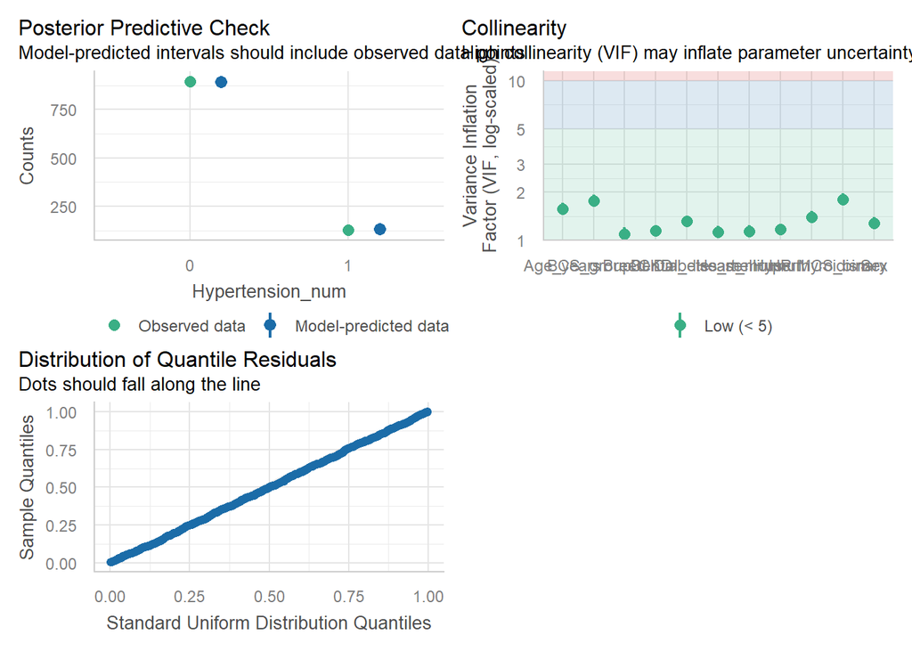

```r
check_collinearity(gee_ht2)
```

```
## # Check for Multicollinearity
##
## Low Correlation
##
##               Term  VIF   VIF 95% CI adj. VIF Tolerance Tolerance 95% CI
##          Age_years 1.57 [1.46, 1.72]     1.25      0.64     [0.58, 0.69]
##                Sex 1.29 [1.21, 1.40]     1.13      0.78     [0.71, 0.83]
##              Breed 1.10 [1.05, 1.21]     1.05      0.91     [0.83, 0.95]
##                 HR 1.17 [1.11, 1.27]     1.08      0.85     [0.78, 0.90]
##         BCS_group3 1.77 [1.63, 1.94]     1.33      0.57     [0.52, 0.61]
##         MCS_binary 1.80 [1.66, 1.97]     1.34      0.56     [0.51, 0.60]
##  Diabetes_mellitus 1.13 [1.07, 1.23]     1.06      0.88     [0.81, 0.93]
##                CKD 1.15 [1.09, 1.25]     1.07      0.87     [0.80, 0.92]
##    Hyperthyroidism 1.41 [1.31, 1.53]     1.19      0.71     [0.65, 0.76]
##       Heart_murmur 1.14 [1.08, 1.24]     1.07      0.88     [0.80, 0.92]
##     Dental_disease 1.31 [1.23, 1.43]     1.15      0.76     [0.70, 0.81]
```

##iii. GEE2 for OE score also

```r
Metadata_SBP_gee_oe<-na.omit(Metadata_SBP2[ ,c("Hypertension", "Cat_ID", "Owner_ID", "Age_years", "Sex", "Breed", "BCS_group3", "MCS_binary", "HR", "CKD", "SBP", "Diabetes_mellitus", "Hyperthyroidism", "Heart_murmur", "HR", "Dental_disease", "oe.abnormality_score", "Healthy_visit")])

#create numbered column
Metadata_SBP_gee_oe$Hypertension_num <-
  ifelse(Metadata_SBP_gee_oe$Hypertension == "Yes", 1, 0)

sum(Metadata_SBP_gee_oe$Hypertension_num)
```

```
## [1] 77
```

```r
length(unique(Metadata_SBP_gee_oe$Cat_ID[Metadata_SBP_gee_oe$Hypertension_num=="1"]))
```

```
## [1] 38
```

```r
#change Cat_ID to factor

Metadata_SBP_gee_oe$Cat_ID <- factor(Metadata_SBP_gee_oe$Cat_ID)
#run model

gee_ht_oe <- geeglm(
  Hypertension_num ~ Age_years + Sex + Breed + HR + BCS_group3 + MCS_binary +
    CKD + Hyperthyroidism  + Heart_murmur + Diabetes_mellitus  + Dental_disease +oe.abnormality_score,
  data = Metadata_SBP_gee_oe,
  id = Cat_ID,
  family = binomial,
  corstr = "exchangeable"
)

#tab model

tbl_regression(gee_ht_oe,  pvalue_fun = label_style_pvalue(digits = 3), exp=TRUE)%>%add_n(location="level")
```

| **Characteristic** | **N** | **OR** | **95% CI** | **p-value** |
| --- | --- | --- | --- | --- |
| Age_years | 569 | 1.33 | 1.05, 1.68 | 0.018 |
| Sex |  |  |  |  |
| Female | 265 | — | — |  |
| Male | 304 | 5.50 | 1.87, 16.2 | 0.002 |
| Breed |  |  |  |  |
| Non-pedigree | 487 | — | — |  |
| Pedigree | 82 | 0.90 | 0.30, 2.65 | 0.848 |
| HR | 569 | 1.01 | 1.00, 1.02 | 0.071 |
| BCS_group3 |  |  |  |  |
| 5 | 165 | — | — |  |
| 1-4 | 83 | 2.42 | 0.80, 7.27 | 0.116 |
| 6 | 140 | 1.44 | 0.54, 3.86 | 0.464 |
| 7-9 | 181 | 3.71 | 1.39, 9.89 | 0.009 |
| MCS_binary |  |  |  |  |
| No | 227 | — | — |  |
| Yes | 342 | 1.85 | 0.76, 4.51 | 0.175 |
| CKD |  |  |  |  |
| No | 504 | — | — |  |
| Yes | 65 | 1.90 | 0.72, 5.01 | 0.193 |
| Hyperthyroidism |  |  |  |  |
| No | 532 | — | — |  |
| Yes | 37 | 6.64 | 2.49, 17.7 | <0.001 |
| Heart_murmur |  |  |  |  |
| No | 369 | — | — |  |
| Yes | 200 | 1.15 | 0.59, 2.25 | 0.675 |
| Diabetes_mellitus |  |  |  |  |
| No | 563 | — | — |  |
| Yes | 6 | 1.11 | 0.13, 9.62 | 0.922 |
| Dental_disease |  |  |  |  |
| No | 230 | — | — |  |
| Yes | 339 | 0.79 | 0.43, 1.47 | 0.464 |
| oe.abnormality_score | 569 | 1.10 | 1.01, 1.19 | 0.022 |

Abbreviations: CI = Confidence Interval, OR = Odds Ratio

```r
tab_model(gee_ht_oe)
```

|  | Hypertension num |  |  |
| --- | --- | --- | --- |
| Predictors | Odds Ratios | CI | p |
| (Intercept) | 0.00 | 0.00 – 0.00 | **<0.001** |
| Age years | 1.33 | 1.05 – 1.68 | **0.018** |
| Sex [Male] | 5.50 | 1.87 – 16.16 | **0.002** |
| Breed [Pedigree] | 0.90 | 0.30 – 2.65 | 0.848 |
| HR | 1.01 | 1.00 – 1.02 | 0.071 |
| BCS_group31-4 | 2.42 | 0.80 – 7.27 | 0.116 |
| BCS group3 [6] | 1.44 | 0.54 – 3.86 | 0.464 |
| BCS_group37-9 | 3.71 | 1.39 – 9.89 | **0.009** |
| MCS binary [Yes] | 1.85 | 0.76 – 4.51 | 0.175 |
| CKD [Yes] | 1.90 | 0.72 – 5.01 | 0.193 |
| Hyperthyroidism [Yes] | 6.64 | 2.49 – 17.69 | **<0.001** |
| Heart murmur [Yes] | 1.15 | 0.59 – 2.25 | 0.675 |
| Diabetes mellitus [Yes] | 1.11 | 0.13 – 9.62 | 0.922 |
| Dental disease [Yes] | 0.79 | 0.43 – 1.47 | 0.464 |
| oe abnormality score | 1.10 | 1.01 – 1.19 | **0.022** |
| N <sub>Cat_ID</sub> | 168 |  |  |
| Observations | 569 |  |  |

#check model

```r
check_collinearity(gee_ht_oe)
```

```
## # Check for Multicollinearity
##
## Low Correlation
##
##                  Term  VIF   VIF 95% CI adj. VIF Tolerance Tolerance 95% CI
##             Age_years 2.53 [2.24, 2.89]     1.59      0.40     [0.35, 0.45]
##                   Sex 1.79 [1.61, 2.02]     1.34      0.56     [0.49, 0.62]
##                 Breed 1.24 [1.14, 1.39]     1.11      0.81     [0.72, 0.87]
##                    HR 1.45 [1.32, 1.63]     1.21      0.69     [0.61, 0.76]
##            BCS_group3 2.96 [2.61, 3.39]     1.72      0.34     [0.29, 0.38]
##            MCS_binary 1.96 [1.75, 2.22]     1.40      0.51     [0.45, 0.57]
##                   CKD 1.32 [1.21, 1.48]     1.15      0.76     [0.68, 0.83]
##       Hyperthyroidism 1.76 [1.59, 1.99]     1.33      0.57     [0.50, 0.63]
##          Heart_murmur 1.41 [1.29, 1.58]     1.19      0.71     [0.63, 0.78]
##     Diabetes_mellitus 1.18 [1.10, 1.33]     1.09      0.84     [0.75, 0.91]
##        Dental_disease 1.60 [1.44, 1.80]     1.26      0.63     [0.56, 0.69]
##  oe.abnormality_score 2.20 [1.96, 2.51]     1.48      0.45     [0.40, 0.51]
```

```r
check_model(gee_ht_oe)
```

```
## Converting missing values (`NA`) into regular values currently not
##   possible for variables of class `NULL`.
```

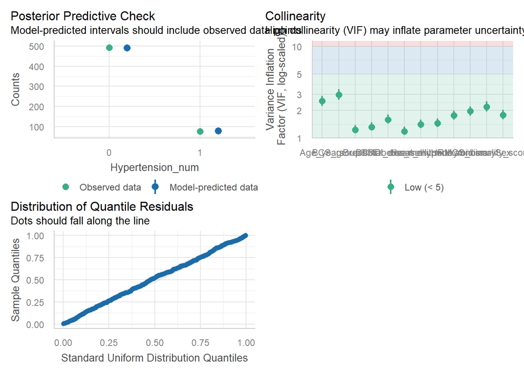

#8. TTE - Cox PH model

##a. sort data ###i. create baseline dataset

```r
Metadata_hyp_baseline <- Metadata_SBP2 %>%
  arrange(Cat_ID, date) %>%
  group_by(Cat_ID) %>%
  slice(1) %>%
  ungroup()
```

###ii. Merge new incidence_data looking at censoring at age at last study visit NOT last study date

```r
Hypertension_incidence_data2170326 <- read.csv("Hypertension_incidence_data2170326.csv")

Metadata_hyp_baseline2 <- Hypertension_incidence_data2170326 %>%
  left_join(
    Metadata_SBP2 %>%
      select(
        Cat_ID_timepoint,
        BCS_group3,
        Heart_murmur,
        HR,
        CKD,
        Hyperthyroidism,
        Dental_disease,
        oe.abnormalities_Yes_no_incomplete,
        MCS_binary,
        SBP
      ),
    by = "Cat_ID_timepoint"
  )

nrow(Metadata_hyp_baseline2)
```

```
## [1] 203
```

```r
colnames(Metadata_hyp_baseline2)
```

```
##  [1] "Cat_ID_timepoint"                   "Cat_ID"
##  [3] "Owner_ID"                           "date"
##  [5] "dob"                                "Age_years"
##  [7] "Breed"                              "Sex"
##  [9] "BCS"                                "MCS_combined"
## [11] "hypertensive_sbp"                   "Hypertension"
## [13] "hypertensive_over.study"            "stHyp"
## [15] "X1st_visit_date"                    "X1st_visit_age"
## [17] "Censor_visit_date"                  "Censor_visit_age"
## [19] "baseline_dx"                        "BCS_group3"
## [21] "Heart_murmur"                       "HR"
## [23] "CKD"                                "Hyperthyroidism"
## [25] "Dental_disease"                     "oe.abnormalities_Yes_no_incomplete"
## [27] "MCS_binary"                         "SBP"
```

```r
#no BCS <3 at baseline -change name of BCS_group to account for this
Metadata_hyp_baseline2 <-
Metadata_hyp_baseline2 %>%
  mutate(BCS_group3 = case_when(
    BCS  %in% 3:4 ~ "3-4",
    BCS  == 5 ~ "5",
    BCS  == 6 ~ "6",
    BCS %in% 7:9 ~ "7-9",
    TRUE ~ NA_character_
  ))
Metadata_hyp_baseline2$BCS_group3
```

```
##   [1] "7-9" "7-9" "6"   "6"   "7-9" "3-4" "7-9" "6"   "5"   "7-9" "5"   "3-4"
##  [13] "5"   "7-9" "6"   "6"   "3-4" "3-4" "3-4" "5"   "7-9" "3-4" "5"   "6"
##  [25] "3-4" "6"   "5"   "7-9" "7-9" "6"   "3-4" "3-4" "7-9" "7-9" "3-4" "6"
##  [37] "6"   "3-4" "3-4" "5"   "5"   "5"   "3-4" "5"   "7-9" "6"   "5"   "5"
##  [49] "7-9" "5"   "3-4" "6"   "6"   "6"   "5"   "3-4" "7-9" "3-4" "6"   "7-9"
##  [61] "5"   "6"   "6"   "7-9" "5"   "3-4" "6"   "7-9" "6"   "5"   "3-4" "6"
##  [73] "7-9" "7-9" "7-9" "7-9" "5"   "7-9" "6"   "5"   "7-9" "5"   "3-4" "5"
##  [85] "6"   "6"   "6"   "7-9" "7-9" "6"   "5"   "5"   "5"   "3-4" "3-4" "7-9"
##  [97] "3-4" "6"   "3-4" "7-9" "3-4" "5"   "6"   "7-9" "7-9" "5"   "7-9" "6"
## [109] "5"   "5"   "6"   "3-4" "5"   "5"   "6"   "5"   "7-9" "6"   "7-9" "7-9"
## [121] "5"   "7-9" "5"   "6"   "6"   "7-9" "6"   "5"   "3-4" "5"   "6"   "6"
## [133] "7-9" "7-9" "5"   "6"   "7-9" "7-9" "5"   "6"   "3-4" "7-9" "7-9" "7-9"
## [145] "7-9" "6"   "5"   "5"   "7-9" "6"   "6"   "7-9" "6"   "7-9" "7-9" "7-9"
## [157] "7-9" "3-4" "7-9" "6"   "5"   "7-9" "7-9" "7-9" "6"   "5"   "7-9" "5"
## [169] "3-4" "5"   "7-9" "6"   "5"   "6"   "6"   "6"   "5"   "5"   "7-9" "7-9"
## [181] "5"   "3-4" "5"   "7-9" "7-9" "7-9" "5"   "5"   "7-9" "7-9" "5"   "6"
## [193] "6"   "3-4" "3-4" "5"   "5"   "5"   "7-9" "7-9" "7-9" "6"   "6"
```

```r
#set ref bcs category as 5
Metadata_hyp_baseline2  <- Metadata_hyp_baseline2 %>%
  mutate(BCS_group3 = factor(
    BCS_group3,
    levels = c("5", "3-4", "6", "7-9")
  ))
```

####iii. remove those cats diagnosed at baseline

```r
Metadata_hyp_baseline2<-Metadata_hyp_baseline2%>%
  filter(baseline_dx =="No")
```

##b. Check MCS missingness

```r
#there are 11 missing MCS at baseline. does MCS affect hypertension risk?

cox_mcs<-coxph(Surv(Censor_visit_age, stHyp ) ~ MCS_combined,
                    data = Metadata_hyp_baseline2)

summary(cox_mcs)#not significant
```

```
## Call:
## coxph(formula = Surv(Censor_visit_age, stHyp) ~ MCS_combined,
##     data = Metadata_hyp_baseline2)
##
##   n= 185, number of events= 31
##    (11 observations deleted due to missingness)
##
##                 coef exp(coef) se(coef)     z Pr(>|z|)
## MCS_combined -0.0505    0.9508   0.0887 -0.57     0.57
##
##              exp(coef) exp(-coef) lower .95 upper .95
## MCS_combined     0.951       1.05     0.799      1.13
##
## Concordance= 0.511  (se = 0.046 )
## Likelihood ratio test= 0.3  on 1 df,   p=0.6
## Wald test            = 0.32  on 1 df,   p=0.6
## Score (logrank) test = 0.33  on 1 df,   p=0.6
```

```r
tab_model(cox_mcs)
```

|  | Surv(Censor visit age,st Hyp) |  |  |
| --- | --- | --- | --- |
| Predictors | Estimates | CI | p |
| MCS combined | 0.95 | 0.80 – 1.13 | 0.569 |
| Observations | 185 |  |  |
| R<sup>2</sup> Nagelkerke | 0.002 |  |  |

```r
#and binary?

cox_mcs<-coxph(Surv(Censor_visit_age, stHyp ) ~ MCS_binary,
                    data = Metadata_hyp_baseline2)

summary(cox_mcs)#not significant
```

```
## Call:
## coxph(formula = Surv(Censor_visit_age, stHyp) ~ MCS_binary, data = Metadata_hyp_baseline2)
##
##   n= 185, number of events= 31
##    (11 observations deleted due to missingness)
##
##                coef exp(coef) se(coef)    z Pr(>|z|)
## MCS_binaryYes 0.516     1.676    0.410 1.26     0.21
##
##               exp(coef) exp(-coef) lower .95 upper .95
## MCS_binaryYes      1.68      0.597      0.75      3.75
##
## Concordance= 0.512  (se = 0.044 )
## Likelihood ratio test= 1.48  on 1 df,   p=0.2
## Wald test            = 1.58  on 1 df,   p=0.2
## Score (logrank) test = 1.62  on 1 df,   p=0.2
```

```r
tab_model(cox_mcs)
```

|  | Surv(Censor visit age,st Hyp) |  |  |
| --- | --- | --- | --- |
| Predictors | Estimates | CI | p |
| MCS binary [Yes] | 1.68 | 0.75 – 3.75 | 0.208 |
| Observations | 185 |  |  |
| R<sup>2</sup> Nagelkerke | 0.011 |  |  |

#####MCS not significant and missingness biases model - remove variable

##c. create complete case dataset

```r
#complete cases

Metadata_hyp_baseline_for_cox<-na.omit(Metadata_hyp_baseline2[,c("Cat_ID", "Age_years", "Censor_visit_age", "stHyp", "Sex", "SBP", "Breed", "BCS_group3")])

dim(Metadata_hyp_baseline_for_cox)
```

```
## [1] 196   8
```

```r
median(Metadata_hyp_baseline_for_cox$Age_years)
```

```
## [1] 8.13
```

```r
quantile(Metadata_hyp_baseline_for_cox$Age_years, 0.25)
```

```
##  25%
## 7.23
```

```r
quantile(Metadata_hyp_baseline_for_cox$Age_years, 0.75)
```

```
##  75%
## 9.25
```

```r
min(Metadata_hyp_baseline_for_cox$Age_years)
```

```
## [1] 6.67
```

```r
max(Metadata_hyp_baseline_for_cox$Age_years)
```

```
## [1] 11.2
```

```r
Metadata_hyp_baseline_for_cox%>%
  filter(stHyp==2)
```

```
##    Cat_ID Age_years Censor_visit_age stHyp    Sex SBP        Breed BCS_group3
## 1  Cat006      7.52            10.13     2   Male 153     Pedigree        3-4
## 2  Cat007      7.03            11.18     2   Male 141     Pedigree        7-9
## 3  Cat011      7.11            11.87     2 Female 116 Non-pedigree          5
## 4  Cat026      9.19            13.21     2   Male 122 Non-pedigree          6
## 5  Cat028      9.56            14.66     2 Female 113 Non-pedigree        7-9
## 6  Cat029      9.56            14.66     2 Female 115 Non-pedigree        7-9
## 7  Cat034      9.00            13.51     2 Female 137 Non-pedigree        7-9
## 8  Cat038      9.82            13.07     2   Male 152 Non-pedigree        3-4
## 9  Cat042      9.93            14.38     2   Male 127 Non-pedigree          5
## 10 Cat045      8.36            12.30     2   Male 140 Non-pedigree        7-9
## 11 Cat048      9.10            12.30     2   Male 108 Non-pedigree          5
## 12 Cat056      9.50            14.14     2   Male 111 Non-pedigree        3-4
## 13 Cat072      7.23            11.38     2   Male 128 Non-pedigree          6
## 14 Cat076      7.77            12.43     2 Female 130 Non-pedigree        7-9
```

[output cut: 20 more lines]

##d. examine healthy visits only

```r
#exmaine healthy visits only?

#merge healthy_visit
Metadata_hyp_baseline_3 <- merge(
  Metadata_hyp_baseline2,
  Metadata_SBP2[, c("Cat_ID_timepoint", "Healthy_visit")],
  by = "Cat_ID_timepoint",
  all = FALSE
)
#make healthy the reference
Metadata_hyp_baseline_3  <- Metadata_hyp_baseline_3 %>%
  mutate(Healthy_visit= factor(
   Healthy_visit,
    levels = c("Yes", "No" )
  ))

colnames(Metadata_hyp_baseline_3)
```

```
##  [1] "Cat_ID_timepoint"                   "Cat_ID"
##  [3] "Owner_ID"                           "date"
##  [5] "dob"                                "Age_years"
##  [7] "Breed"                              "Sex"
##  [9] "BCS"                                "MCS_combined"
## [11] "hypertensive_sbp"                   "Hypertension"
## [13] "hypertensive_over.study"            "stHyp"
## [15] "X1st_visit_date"                    "X1st_visit_age"
## [17] "Censor_visit_date"                  "Censor_visit_age"
## [19] "baseline_dx"                        "BCS_group3"
## [21] "Heart_murmur"                       "HR"
## [23] "CKD"                                "Hyperthyroidism"
## [25] "Dental_disease"                     "oe.abnormalities_Yes_no_incomplete"
## [27] "MCS_binary"                         "SBP"
## [29] "Healthy_visit"
```

##e. inital Cox model exploring adding morbidities

```r
cox_1<-coxph(Surv(Censor_visit_age, stHyp ) ~ Sex + Breed + SBP + BCS_group3 + Heart_murmur + HR + CKD + Hyperthyroidism, data =  Metadata_hyp_baseline2)
tbl_regression(cox_1, exp=T)%>% add_n(location="level")
```

| **Characteristic** | **N** | **HR** | **95% CI** | **p-value** |
| --- | --- | --- | --- | --- |
| Sex |  |  |  |  |
| Female | 102 | — | — |  |
| Male | 88 | 2.58 | 1.16, 5.78 | 0.021 |
| Breed |  |  |  |  |
| Non-pedigree | 163 | — | — |  |
| Pedigree | 27 | 1.21 | 0.37, 3.96 | 0.7 |
| SBP | 190 | 1.03 | 1.01, 1.06 | 0.007 |
| BCS_group3 |  |  |  |  |
| 5 | 54 | — | — |  |
| 3-4 | 29 | 1.78 | 0.52, 6.14 | 0.4 |
| 6 | 47 | 0.99 | 0.28, 3.57 | >0.9 |
| 7-9 | 60 | 3.05 | 1.17, 7.98 | 0.023 |
| Heart_murmur |  |  |  |  |
| No | 135 | — | — |  |
| Yes | 55 | 0.53 | 0.21, 1.29 | 0.2 |
| HR | 190 | 1.00 | 0.98, 1.02 | 0.8 |
| CKD |  |  |  |  |
| No | 180 | — | — |  |
| Yes | 10 | 1.22 | 0.23, 6.51 | 0.8 |
| Hyperthyroidism |  |  |  |  |
| No | 186 | — | — |  |
| Yes | 4 | 0.00 | 0.00, Inf | >0.9 |

Abbreviations: CI = Confidence Interval, HR = Hazard Ratio

```r
# unable to model with hyperthyroidism - unstable coefficient. Remove? CKD also limitis event numbers

cox_2<-coxph(Surv(Censor_visit_age, stHyp ) ~ Sex + Breed + BCS_group3 + MCS_binary + Heart_murmur +CKD +Dental_disease + oe.abnormalities_Yes_no_incomplete, data = Metadata_hyp_baseline2)

tbl_regression(cox_2, exp=T)%>% add_n(location="level")
```

| **Characteristic** | **N** | **HR** | **95% CI** | **p-value** |
| --- | --- | --- | --- | --- |
| Sex |  |  |  |  |
| Female | 97 | — | — |  |
| Male | 86 | 2.65 | 1.18, 5.96 | 0.018 |
| Breed |  |  |  |  |
| Non-pedigree | 156 | — | — |  |
| Pedigree | 27 | 1.70 | 0.52, 5.54 | 0.4 |
| BCS_group3 |  |  |  |  |
| 5 | 52 | — | — |  |
| 3-4 | 28 | 2.14 | 0.63, 7.26 | 0.2 |
| 6 | 47 | 0.78 | 0.21, 2.81 | 0.7 |
| 7-9 | 56 | 3.05 | 1.11, 8.36 | 0.030 |
| MCS_binary |  |  |  |  |
| No | 128 | — | — |  |
| Yes | 55 | 1.72 | 0.69, 4.28 | 0.2 |
| Heart_murmur |  |  |  |  |
| No | 127 | — | — |  |
| Yes | 56 | 0.46 | 0.17, 1.23 | 0.12 |
| CKD |  |  |  |  |
| No | 173 | — | — |  |
| Yes | 10 | 3.33 | 0.52, 21.2 | 0.2 |
| Dental_disease |  |  |  |  |
| No | 71 | — | — |  |
| Yes | 112 | 0.63 | 0.28, 1.38 | 0.2 |
| oe.abnormalities_Yes_no_incomplete |  |  |  |  |
| No | 48 | — | — |  |
| Incomplete_OE | 11 | 19.4 | 2.87, 131 | 0.002 |
| Yes | 124 | 3.98 | 1.09, 14.5 | 0.037 |

Abbreviations: CI = Confidence Interval, HR = Hazard Ratio

```r
#strip down to healthy visit rather tahn co-morbs

cox_3<-coxph(Surv(Censor_visit_age, stHyp ) ~ Sex + Breed + BCS_group3 + MCS_binary + Healthy_visit, data = Metadata_hyp_baseline_3)

tbl_regression(cox_3, exp=T)%>% add_n(location="level")
```

| **Characteristic** | **N** | **HR** | **95% CI** | **p-value** |
| --- | --- | --- | --- | --- |
| Sex |  |  |  |  |
| Female | 99 | — | — |  |
| Male | 86 | 2.53 | 1.14, 5.63 | 0.023 |
| Breed |  |  |  |  |
| Non-pedigree | 158 | — | — |  |
| Pedigree | 27 | 1.69 | 0.58, 4.89 | 0.3 |
| BCS_group3 |  |  |  |  |
| 5 | 52 | — | — |  |
| 3-4 | 28 | 1.73 | 0.51, 5.83 | 0.4 |
| 6 | 48 | 1.17 | 0.38, 3.59 | 0.8 |
| 7-9 | 57 | 3.55 | 1.27, 9.96 | 0.016 |
| MCS_binary |  |  |  |  |
| No | 130 | — | — |  |
| Yes | 55 | 1.92 | 0.81, 4.55 | 0.14 |
| Healthy_visit |  |  |  |  |
| Yes | 134 | — | — |  |
| No | 51 | 0.55 | 0.20, 1.51 | 0.2 |

Abbreviations: CI = Confidence Interval, HR = Hazard Ratio

```r
cox.zph(cox_3)
```

```
##                 chisq df     p
## Sex            0.0343  1 0.853
## Breed          0.7912  1 0.374
## BCS_group3     3.5492  3 0.314
## MCS_binary     5.6851  1 0.017
## Healthy_visit  1.0205  1 0.312
## GLOBAL        11.9125  7 0.103
```

```r
##issues - low event numbers of certain morbidities, healthy overall creates bias as unhealthy cats likely die earlier and are censored
```

##f. take healthy visit at baseline data only

```r
cox_healthy_data<-Metadata_hyp_baseline_3%>%
  filter(Healthy_visit=="Yes")
cox_healthy<-coxph(Surv(Censor_visit_age, stHyp ) ~ Sex + Breed + BCS_group3 + MCS_binary, data = cox_healthy_data)

tbl_regression(cox_healthy, exp=T)%>% add_n(location="level")
```

| **Characteristic** | **N** | **HR** | **95% CI** | **p-value** |
| --- | --- | --- | --- | --- |
| Sex |  |  |  |  |
| Female | 73 | — | — |  |
| Male | 61 | 2.68 | 1.12, 6.44 | 0.027 |
| Breed |  |  |  |  |
| Non-pedigree | 115 | — | — |  |
| Pedigree | 19 | 1.77 | 0.55, 5.71 | 0.3 |
| BCS_group3 |  |  |  |  |
| 5 | 42 | — | — |  |
| 3-4 | 19 | 1.87 | 0.55, 6.34 | 0.3 |
| 6 | 33 | 0.91 | 0.27, 3.07 | 0.9 |
| 7-9 | 40 | 3.37 | 1.17, 9.71 | 0.024 |
| MCS_binary |  |  |  |  |
| No | 102 | — | — |  |
| Yes | 32 | 1.54 | 0.57, 4.18 | 0.4 |

Abbreviations: CI = Confidence Interval, HR = Hazard Ratio

```r
#low sample size!
```

##g. forget about morbidities. Model using clinical data

```r
#all
cox_hyprisk<-coxph(Surv(Censor_visit_age, stHyp ) ~ Sex + Breed + SBP +
                     BCS_group3,
                   data = Metadata_hyp_baseline_for_cox)

tbl_regression(cox_hyprisk, exp=T)%>%add_n(location=c("level"))
```

| **Characteristic** | **N** | **HR** | **95% CI** | **p-value** |
| --- | --- | --- | --- | --- |
| Sex |  |  |  |  |
| Female | 105 | — | — |  |
| Male | 91 | 2.43 | 1.15, 5.14 | 0.020 |
| Breed |  |  |  |  |
| Non-pedigree | 169 | — | — |  |
| Pedigree | 27 | 1.31 | 0.44, 3.86 | 0.6 |
| SBP | 196 | 1.04 | 1.01, 1.06 | 0.003 |
| BCS_group3 |  |  |  |  |
| 5 | 54 | — | — |  |
| 3-4 | 29 | 1.73 | 0.51, 5.91 | 0.4 |
| 6 | 50 | 0.96 | 0.30, 3.04 | >0.9 |
| 7-9 | 63 | 3.11 | 1.21, 8.03 | 0.019 |

Abbreviations: CI = Confidence Interval, HR = Hazard Ratio

```r
AIC(cox_hyprisk)
```

```
## [1] 275
```

```r
#remove breed
cox_hyprisk2<-coxph(Surv(Censor_visit_age, stHyp ) ~ Sex + SBP +
                     BCS_group3,
                   data = Metadata_hyp_baseline_for_cox)

tbl_regression(cox_hyprisk2, exp=T)%>%add_n(location=c("level"))
```

| **Characteristic** | **N** | **HR** | **95% CI** | **p-value** |
| --- | --- | --- | --- | --- |
| Sex |  |  |  |  |
| Female | 105 | — | — |  |
| Male | 91 | 2.50 | 1.19, 5.24 | 0.016 |
| SBP | 196 | 1.04 | 1.01, 1.06 | 0.002 |
| BCS_group3 |  |  |  |  |
| 5 | 54 | — | — |  |
| 3-4 | 29 | 1.67 | 0.49, 5.67 | 0.4 |
| 6 | 50 | 1.02 | 0.33, 3.13 | >0.9 |
| 7-9 | 63 | 3.05 | 1.19, 7.84 | 0.020 |

Abbreviations: CI = Confidence Interval, HR = Hazard Ratio

```r
AIC(cox_hyprisk2)
```

```
## [1] 273
```

```r
#SBP alone
cox_hyprisk3<-coxph(Surv(Censor_visit_age, stHyp ) ~ SBP,
                   data = Metadata_hyp_baseline_for_cox)

tbl_regression(cox_hyprisk3, exp=T)%>%add_n(location=c("level"))
```

| **Characteristic** | **N** | **HR** | **95% CI** | **p-value** |
| --- | --- | --- | --- | --- |
| SBP | 196 | 1.03 | 1.01, 1.06 | 0.003 |

Abbreviations: CI = Confidence Interval, HR = Hazard Ratio

```r
AIC(cox_hyprisk3)
```

```
## [1] 278
```

```r
AIC(cox_hyprisk, cox_hyprisk2, cox_hyprisk3)#cox_2 best fit
```

```
##              df AIC
## cox_hyprisk   6 275
## cox_hyprisk2  5 273
## cox_hyprisk3  1 278
```

```r
summary(cox_hyprisk2)
```

```
## Call:
## coxph(formula = Surv(Censor_visit_age, stHyp) ~ Sex + SBP + BCS_group3,
##     data = Metadata_hyp_baseline_for_cox)
##
##   n= 196, number of events= 34
##
##                 coef exp(coef) se(coef)    z Pr(>|z|)
## SexMale       0.9147    2.4961   0.3781 2.42   0.0155 *
## SBP           0.0352    1.0358   0.0114 3.08   0.0021 **
## BCS_group33-4 0.5137    1.6714   0.6236 0.82   0.4101
## BCS_group36   0.0218    1.0221   0.5714 0.04   0.9695
## BCS_group37-9 1.1155    3.0510   0.4814 2.32   0.0205 *
## ---
## Signif. codes:  0 '***' 0.001 '**' 0.01 '*' 0.05 '.' 0.1 ' ' 1
##
##               exp(coef) exp(-coef) lower .95 upper .95
## SexMale            2.50      0.401     1.190      5.24
## SBP                1.04      0.965     1.013      1.06
## BCS_group33-4      1.67      0.598     0.492      5.67
## BCS_group36        1.02      0.978     0.333      3.13
## BCS_group37-9      3.05      0.328     1.188      7.84
##
## Concordance= 0.73  (se = 0.043 )
## Likelihood ratio test= 21.4  on 5 df,   p=7e-04
## Wald test            = 19.8  on 5 df,   p=0.001
## Score (logrank) test = 21  on 5 df,   p=8e-04
```

###i. BEST MODEL

```r
summary(cox_hyprisk2)
```

```
## Call:
## coxph(formula = Surv(Censor_visit_age, stHyp) ~ Sex + SBP + BCS_group3,
##     data = Metadata_hyp_baseline_for_cox)
##
##   n= 196, number of events= 34
##
##                 coef exp(coef) se(coef)    z Pr(>|z|)
## SexMale       0.9147    2.4961   0.3781 2.42   0.0155 *
## SBP           0.0352    1.0358   0.0114 3.08   0.0021 **
## BCS_group33-4 0.5137    1.6714   0.6236 0.82   0.4101
## BCS_group36   0.0218    1.0221   0.5714 0.04   0.9695
## BCS_group37-9 1.1155    3.0510   0.4814 2.32   0.0205 *
## ---
## Signif. codes:  0 '***' 0.001 '**' 0.01 '*' 0.05 '.' 0.1 ' ' 1
##
##               exp(coef) exp(-coef) lower .95 upper .95
## SexMale            2.50      0.401     1.190      5.24
## SBP                1.04      0.965     1.013      1.06
## BCS_group33-4      1.67      0.598     0.492      5.67
## BCS_group36        1.02      0.978     0.333      3.13
## BCS_group37-9      3.05      0.328     1.188      7.84
##
## Concordance= 0.73  (se = 0.043 )
## Likelihood ratio test= 21.4  on 5 df,   p=7e-04
## Wald test            = 19.8  on 5 df,   p=0.001
## Score (logrank) test = 21  on 5 df,   p=8e-04
```

```r
tbl_regression(cox_hyprisk2, pvalue_fun= label_style_pvalue(digits = 3), exp=T)%>%add_n(location=c("level"))
```

| **Characteristic** | **N** | **HR** | **95% CI** | **p-value** |
| --- | --- | --- | --- | --- |
| Sex |  |  |  |  |
| Female | 105 | — | — |  |
| Male | 91 | 2.50 | 1.19, 5.24 | 0.016 |
| SBP | 196 | 1.04 | 1.01, 1.06 | 0.002 |
| BCS_group3 |  |  |  |  |
| 5 | 54 | — | — |  |
| 3-4 | 29 | 1.67 | 0.49, 5.67 | 0.410 |
| 6 | 50 | 1.02 | 0.33, 3.13 | 0.970 |
| 7-9 | 63 | 3.05 | 1.19, 7.84 | 0.020 |

Abbreviations: CI = Confidence Interval, HR = Hazard Ratio

###ii. check PH assumptions

```r
cox.zph(cox_hyprisk2)
```

```
##             chisq df    p
## Sex        0.0198  1 0.89
## SBP        0.0809  1 0.78
## BCS_group3 3.9355  3 0.27
## GLOBAL     4.0341  5 0.54
```

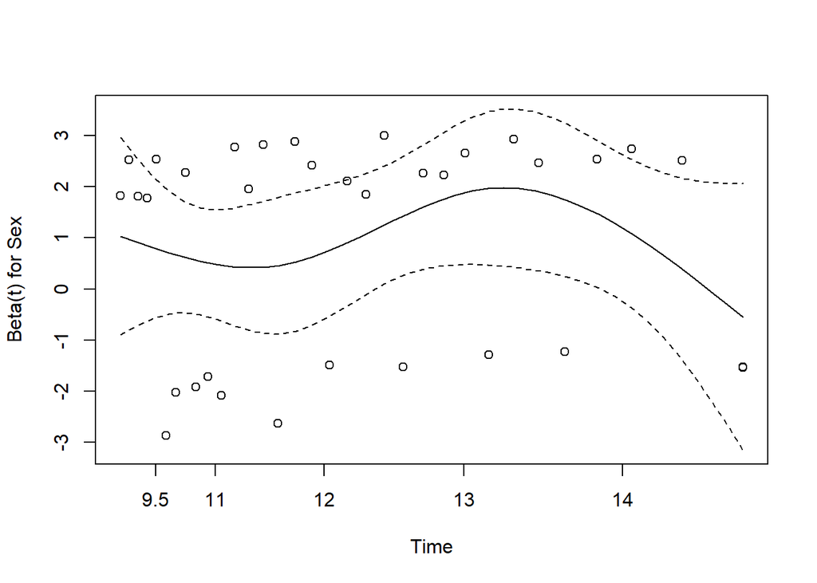

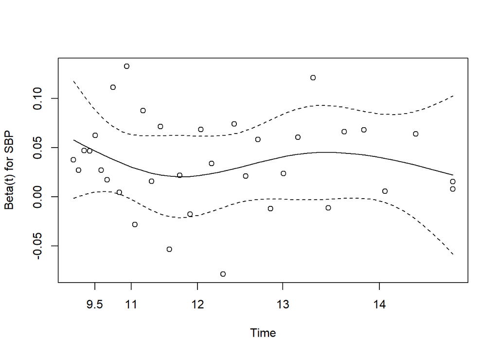

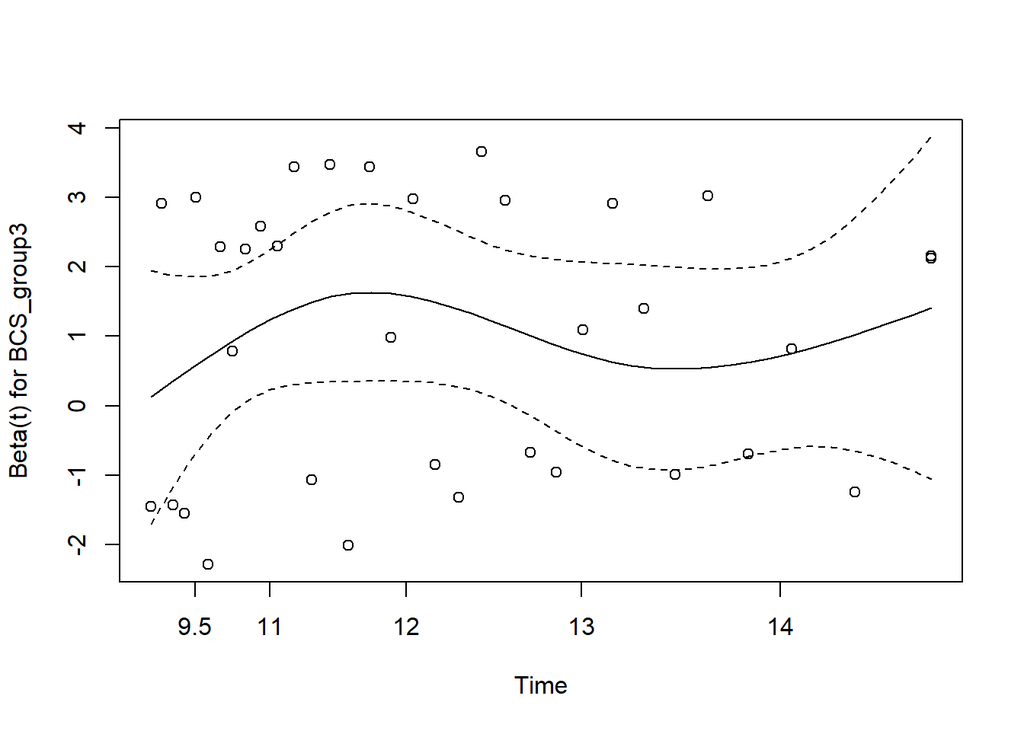

```r
plot(cox.zph(cox_hyprisk2))
```

###iii. check outliers

```r
# Standardized dfbeta residuals
residuals(cox_hyprisk2, type = "dfbeta")
```

```
##          [,1]      [,2]      [,3]      [,4]      [,5]
## 1   -4.07e-03  4.06e-04  2.97e-04 -4.85e-04 -5.23e-03
## 2   -1.13e-01  8.33e-04 -1.36e-03  1.06e-02 -1.16e-01
## 3    0.00e+00  0.00e+00  0.00e+00  0.00e+00  0.00e+00
## 4    0.00e+00  0.00e+00  0.00e+00  0.00e+00  0.00e+00
## 5    7.74e-02 -4.68e-03  4.50e-03  8.50e-03 -8.15e-02
## 6    1.72e-02  1.63e-03  1.47e-01 -1.28e-02 -7.45e-03
## 7    4.31e-02  1.24e-03 -1.64e-02 -2.11e-02  4.35e-02
## 8    1.15e-02  2.50e-04 -3.73e-03 -1.72e-02  3.02e-04
## 9    1.93e-04  6.88e-07  3.45e-04  3.15e-04  3.95e-04
## 10   0.00e+00  0.00e+00  0.00e+00  0.00e+00  0.00e+00
## 11  -8.28e-02 -2.21e-03 -1.36e-01 -1.35e-01 -1.63e-01
## 12   1.32e-03  4.06e-05 -2.27e-03 -5.43e-04  1.45e-04
## 13  -1.22e-02  2.03e-04  3.90e-02  3.78e-02  3.44e-02
## 14   8.01e-03  3.86e-04 -3.22e-03 -3.62e-03 -5.11e-03
```

[output cut: 182 more lines]

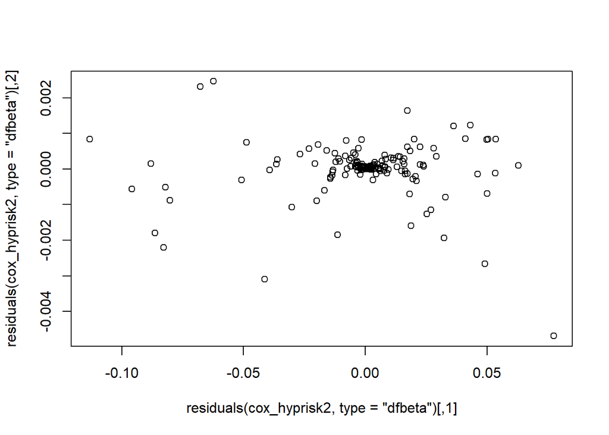

```r
plot(residuals(cox_hyprisk2, type = "dfbeta"))  # look for points far from 0
```

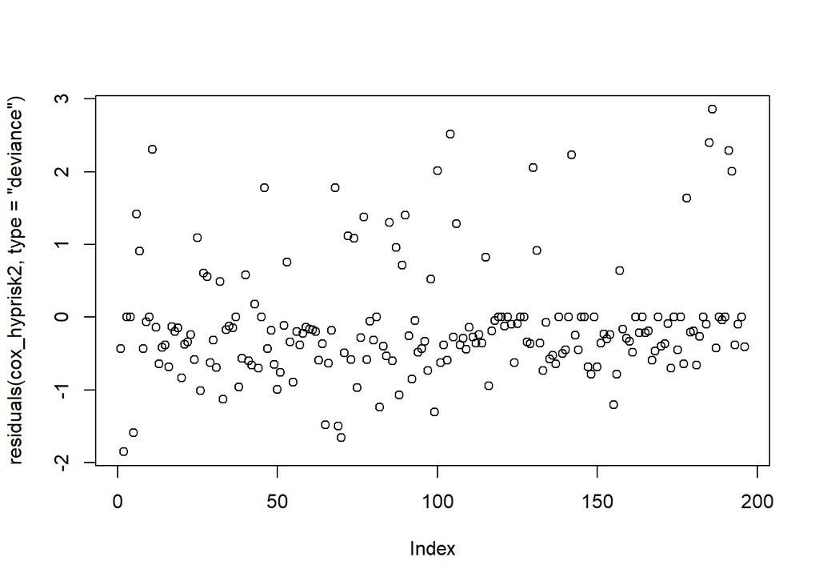

```r
# Deviance residuals
plot(residuals(cox_hyprisk2, type = "deviance"))
```

###iv. check linearity of SBP

```r
# Fit model with a penalized spline for SBP
cox_spline <- coxph(Surv(Censor_visit_age, stHyp) ~ ns(SBP, df=2) + Sex + BCS_group3,
                    data = Metadata_hyp_baseline_for_cox)
summary(cox_spline)  # or compare log-likelihood to linear model
```

```
## Call:
## coxph(formula = Surv(Censor_visit_age, stHyp) ~ ns(SBP, df = 2) +
##     Sex + BCS_group3, data = Metadata_hyp_baseline_for_cox)
##
##   n= 196, number of events= 34
##
##                       coef exp(coef)  se(coef)     z Pr(>|z|)
## ns(SBP, df = 2)1  9.28e+00  1.08e+04  3.01e+00  3.08   0.0021 **
## ns(SBP, df = 2)2  9.80e-01  2.66e+00  1.34e+00  0.73   0.4650
## SexMale           8.34e-01  2.30e+00  3.78e-01  2.21   0.0271 *
## BCS_group33-4     7.43e-01  2.10e+00  6.30e-01  1.18   0.2381
## BCS_group36      -8.73e-02  9.16e-01  5.72e-01 -0.15   0.8787
## BCS_group37-9     1.12e+00  3.06e+00  4.82e-01  2.32   0.0204 *
## ---
## Signif. codes:  0 '***' 0.001 '**' 0.01 '*' 0.05 '.' 0.1 ' ' 1
##
##                  exp(coef) exp(-coef) lower .95 upper .95
## ns(SBP, df = 2)1  1.08e+04   9.29e-05    29.223  3.96e+06
## ns(SBP, df = 2)2  2.66e+00   3.75e-01     0.192  3.69e+01
## SexMale           2.30e+00   4.34e-01     1.099  4.83e+00
## BCS_group33-4     2.10e+00   4.76e-01     0.612  7.23e+00
## BCS_group36       9.16e-01   1.09e+00     0.299  2.81e+00
## BCS_group37-9     3.06e+00   3.27e-01     1.189  7.87e+00
##
## Concordance= 0.768  (se = 0.038 )
## Likelihood ratio test= 27.5  on 6 df,   p=1e-04
## Wald test            = 21.7  on 6 df,   p=0.001
## Score (logrank) test = 22.4  on 6 df,   p=0.001
```

```r
AIC(cox_hyprisk2, cox_spline)
```

```
##              df AIC
## cox_hyprisk2  5 273
## cox_spline    6 269
```

```r
#some slight imp to model fit but ideally keep the simpler linear model for easier interpretation
```

###v. assess concordance and c-index

```r
#Concordance = 0.730
concordance(cox_hyprisk2)$concordance
```

```
## [1] 0.73
```

```r
summary(cox_hyprisk2)
```

```
## Call:
## coxph(formula = Surv(Censor_visit_age, stHyp) ~ Sex + SBP + BCS_group3,
##     data = Metadata_hyp_baseline_for_cox)
##
##   n= 196, number of events= 34
##
##                 coef exp(coef) se(coef)    z Pr(>|z|)
## SexMale       0.9147    2.4961   0.3781 2.42   0.0155 *
## SBP           0.0352    1.0358   0.0114 3.08   0.0021 **
## BCS_group33-4 0.5137    1.6714   0.6236 0.82   0.4101
## BCS_group36   0.0218    1.0221   0.5714 0.04   0.9695
## BCS_group37-9 1.1155    3.0510   0.4814 2.32   0.0205 *
## ---
## Signif. codes:  0 '***' 0.001 '**' 0.01 '*' 0.05 '.' 0.1 ' ' 1
##
##               exp(coef) exp(-coef) lower .95 upper .95
## SexMale            2.50      0.401     1.190      5.24
## SBP                1.04      0.965     1.013      1.06
## BCS_group33-4      1.67      0.598     0.492      5.67
## BCS_group36        1.02      0.978     0.333      3.13
## BCS_group37-9      3.05      0.328     1.188      7.84
##
## Concordance= 0.73  (se = 0.043 )
## Likelihood ratio test= 21.4  on 5 df,   p=7e-04
## Wald test            = 19.8  on 5 df,   p=0.001
## Score (logrank) test = 21  on 5 df,   p=8e-04
```

###vi. check for multicollinearity

```r
vif(cox_hyprisk2)
```

```
##       SexMale           SBP BCS_group33-4   BCS_group36 BCS_group37-9
##          1.10          1.03          1.62          1.79          1.92
```

```r
#all VIF<2
```

### vii. bootstrap

```r
# Function to compute coefficients in bootstrap sample
cox_boot_fun <- function(data, indices) {
  d <- data[indices, ]  # resample with replacement
  fit <- coxph(Surv(Censor_visit_age, stHyp) ~ Sex + SBP + BCS_group3, data = d)
  return(coef(fit))  # return coefficients
}

# Run bootstrap
set.seed(123)
boot_results <- boot(data = Metadata_hyp_baseline_for_cox,
                     statistic = cox_boot_fun,
                     R = 1000)  # number of bootstrap samples
# Inspect results
boot_results
```

```
##
## ORDINARY NONPARAMETRIC BOOTSTRAP
##
##
## Call:
## boot(data = Metadata_hyp_baseline_for_cox, statistic = cox_boot_fun,
##     R = 1000)
##
##
## Bootstrap Statistics :
##     original   bias    std. error
## t1*   0.9147  0.07072      0.4281
## t2*   0.0352  0.00342      0.0126
## t3*   0.5137 -0.04494      1.5899
## t4*   0.0218  0.04590      1.2318
## t5*   1.1155  0.11581      1.1957
```

```r
# Bootstrap mean, SD, and 95% CI
apply(boot_results$t, 2, mean)      # mean coefficients
```

```
## [1] 0.9854 0.0386 0.4687 0.0677 1.2313
```

```r
apply(boot_results$t, 2, sd)        # SD of coefficients
```

```
## [1] 0.4281 0.0126 1.5899 1.2318 1.1957
```

```r
# 95% percentile CI
apply(boot_results$t, 2, function(x) quantile(x, probs = c(0.025, 0.975)))
```

```
##        [,1]   [,2]   [,3]  [,4]  [,5]
## 2.5%  0.244 0.0168 -0.815 -1.25 0.209
## 97.5% 1.968 0.0656  1.902  1.38 2.456
```

```r
exp(apply(boot_results$t, 2, mean))  # mean HRs
```

```
## [1] 2.68 1.04 1.60 1.07 3.43
```

```r
exp(apply(boot_results$t, 2, function(x) quantile(x, probs=c(0.025,0.975))))  # 95% CI
```

```
##       [,1] [,2]  [,3]  [,4]  [,5]
## 2.5%  1.28 1.02 0.443 0.287  1.23
## 97.5% 7.16 1.07 6.702 3.972 11.66
```

#### run rms

```r
# Setup for rms functions
dd <- datadist(Metadata_hyp_baseline_for_cox)
options(datadist="dd")

cox_rms <- cph(Surv(Censor_visit_age, stHyp) ~ Sex + SBP + BCS_group3,
               data = Metadata_hyp_baseline_for_cox, x=TRUE, y=TRUE, surv=TRUE)

# Bootstrap validation
set.seed(123)
validate(cox_rms, B=1000, method="boot")  # B=1000 bootstrap samples
```

```
##       index.orig training   test optimism index.corrected   Lower Upper    n
## Dxy       0.4604   0.5042 0.4354   0.0688          0.3916  0.2074 0.571 1000
## R2        0.1348   0.1642 0.1123   0.0520          0.0828 -0.0440 0.181 1000
## Slope     1.0000   1.0000 0.8060   0.1940          0.8060  0.3269 1.354 1000
## D         0.0715   0.0904 0.0585   0.0319          0.0396 -0.0409 0.101 1000
## U        -0.0070  -0.0073 0.0117  -0.0190          0.0120 -0.0110 0.124 1000
## Q         0.0786   0.0976 0.0468   0.0509          0.0277 -0.1398 0.107 1000
## g         1.0430   1.2282 0.9330   0.2952          0.7478 -0.3047 1.266 1000
```

##vii. plot km curve

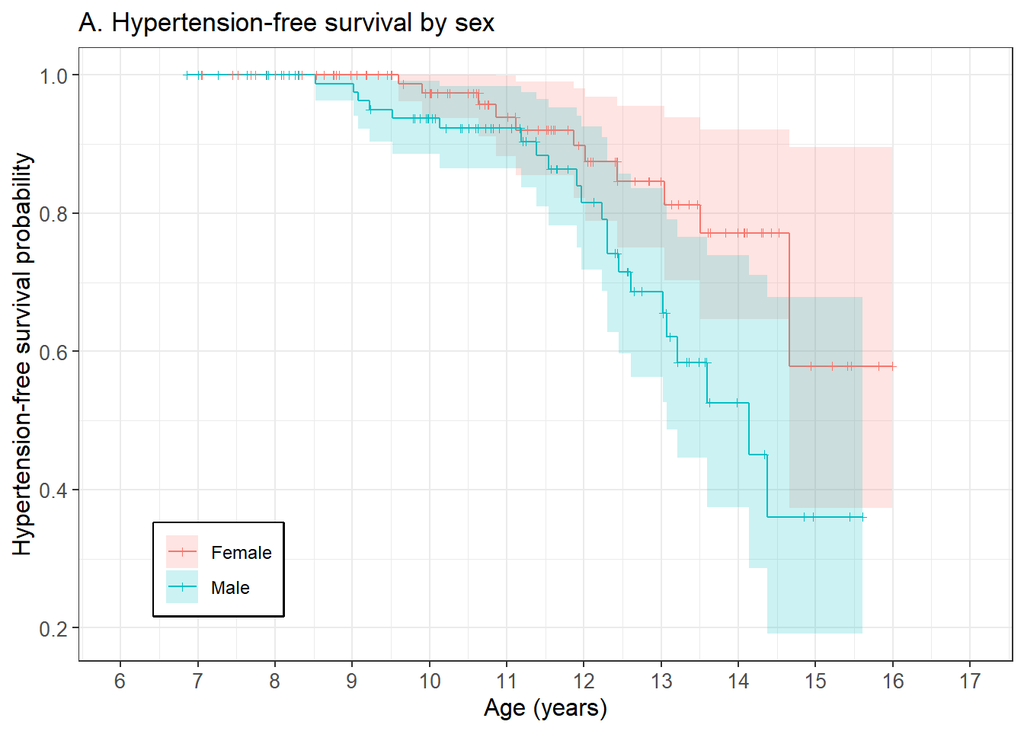

```r
#KM
km1<-survfit2(Surv(Censor_visit_age, stHyp ) ~ Sex, data = Metadata_hyp_baseline_for_cox)%>%
  ggsurvfit() +
  labs(x = "Age (years)", y="Hypertension-free survival probability")+
  ggtitle("A. Hypertension-free survival by sex")+
  #add_risktable()+
  add_confidence_interval()+
  add_censor_mark( size=1)+
  scale_x_continuous(breaks = 6:17, limits = c(6, 17))+
theme(
  legend.position = "inside",
  legend.position.inside = c(0.15, 0.15),
  legend.text=element_text(size=9),
  legend.box.background =  element_rect(colour="black", linewidth = 1),
  legend.title = element_text(size=9),
  legend.title.position="top"
)
km1
```

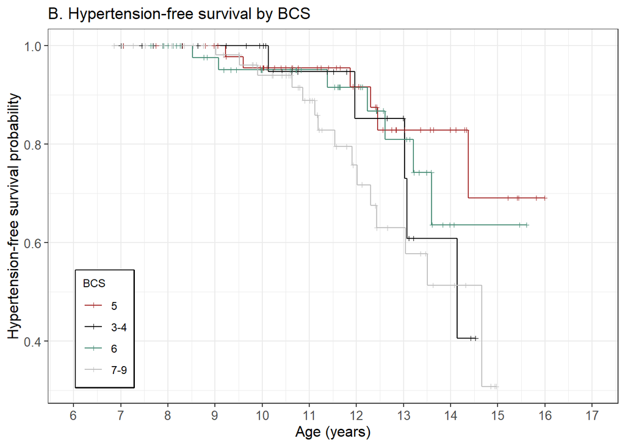

```r
#ggsave("Hypertension_sex_KM_curev170326.png", #plot=last_plot(),height = 2100, width = 2100, #units="px" )


#KM
km2<-survfit2(Surv(Censor_visit_age, stHyp ) ~ BCS_group3, data = Metadata_hyp_baseline_for_cox)%>%
  ggsurvfit() +
  labs(x = "Age (years)", y="Hypertension-free survival probability", color="BCS")+
  ggtitle("B. Hypertension-free survival by BCS")+
 # add_risktable()+
  #add_confidence_interval()+
  scale_color_manual(values=c("3-4" = "black", "5" = "brown", "6" = "aquamarine4", "7-9" = "grey"))+
  add_censor_mark( size=1)+
  scale_x_continuous(breaks = 6:17, limits = c(6, 17))+
  theme(
  legend.position = "inside",
  legend.position.inside = c(0.1, 0.2),
  legend.text=element_text(size=9),
  legend.box.background =  element_rect(colour="black", linewidth = 1),
  legend.title = element_text(size=9)
)
km2
```

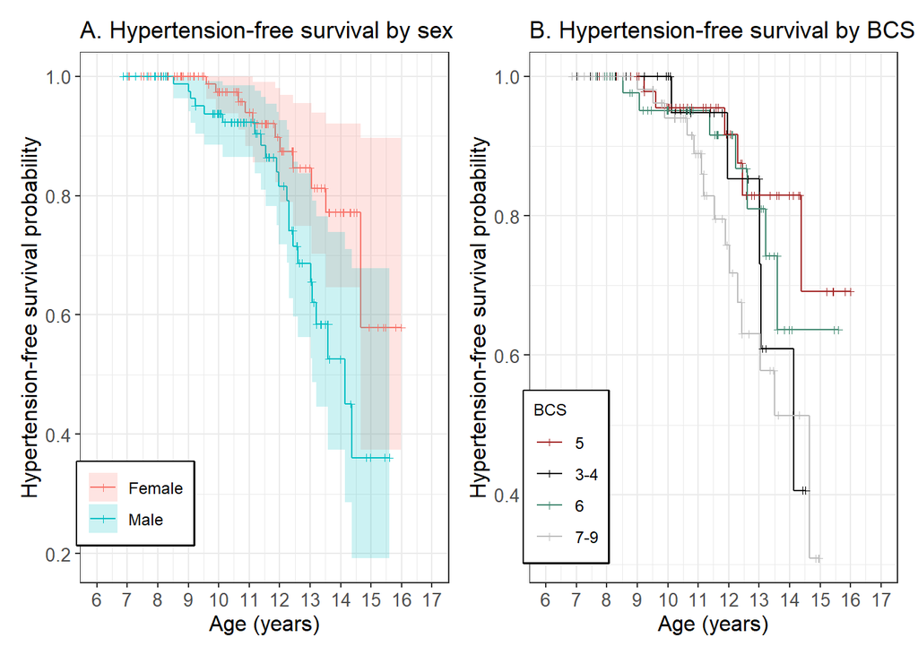

```r
#ggsave("Hypertension_BCS_KM_curev170326.png", #plot=last_plot(),height = 2100, width = 2100, #units="px" )

km1+km2
```

```r
#ggsave("Hypertension_sex_bcs_KM_curve_Figure170326.png"#, plot=last_plot(),height = 15, width = 30, units="cm" #)
```